# Main notebook for the Safety Challenge

This is the main notebook containing the highlights, anaylsis and code for the problem statement.

The notebook is broken down into the sections:

1. Answering and adressing the main problem statements
2. Our process of dealing with the problem

Done by:

- Chuan Hao
  - Github: [@chuanhao01](https://github.com/chuanhao01)
- David
  - Gihub: [@david-the-programmer](https://github.com/david-the-programmer)
- Sherisse
  - Github: [@sherissetjw](https://github.com/sherissetjw)

```python
# Importing Libs needed for the Notebook
import numpy as np
import pandas as pd
import matplotlib.pyplot as plt
import seaborn as sns
import sklearn
```

# Answering and adressing the main problem statements

## 1. Which feature has a high impact on indicating dangerous trips?

To break down this problem statement:

Features in this case will be referring to both trends as well as aggregated features of the trips themselves.  
This is because taking the trip as a time series as well as a single data point, the feature would be different.

As for high impact, this would be categorized as contributing to the trip being dangerous.

Lastly for dangerous trips, in this case, the trip would have a label of 1.

```python
# Loading the data
# For context, the ml_data is the final DataFrame we are using for this anaylsis as well as the ML model later
ml_data = pd.read_csv('/content/drive/MyDrive/grab/ml_data.csv')
ml_data
```

|  | bookingID | Accuracy | Bearing | acceleration_x | acceleration_y | acceleration_z | gyro_x | gyro_y | gyro_z | second | Speed | label | acc_vec | acc_y |
| --- | --- | --- | --- | --- | --- | --- | --- | --- | --- | --- | --- | --- | --- | --- |
| 0 | 0 | 12.0 | 143.298294 | 0.818112 | -9.941461 | -2.014999 | -0.016245 | -0.094040 | 0.070732 | 0.0 | 3.442991 | 0 | 10.176551 | 9.941461 |
| 1 | 0 | 8.0 | 143.298294 | 0.546405 | -9.835590 | -2.038925 | -0.047092 | -0.078874 | 0.043187 | 1.0 | 0.228454 | 0 | 10.059553 | 9.835590 |
| 2 | 0 | 8.0 | 143.298294 | -1.706207 | -9.270792 | -1.209448 | -0.028965 | -0.032652 | 0.015390 | 2.0 | 0.228454 | 0 | 9.503762 | 9.270792 |
| 3 | 0 | 8.0 | 143.298294 | -1.416705 | -9.548032 | -1.860977 | -0.022413 | 0.005049 | -0.025753 | 3.0 | 0.228454 | 0 | 9.830320 | 9.548032 |
| 4 | 0 | 8.0 | 143.298294 | -0.598145 | -9.853534 | -1.378574 | -0.014297 | -0.046206 | 0.021902 | 4.0 | 0.228454 | 0 | 9.967466 | 9.853534 |
| ... | ... | ... | ... | ... | ... | ... | ... | ... | ... | ... | ... | ... | ... | ... |
| 15161680 | 1709396983975 | 8.0 | 199.547104 | -0.320905 | -8.949738 | -3.971979 | -0.012879 | 0.015905 | -0.007625 | 559.0 | 1.035811 | 1 | 9.796805 | 8.949738 |
| 15161681 | 1709396983975 | 8.0 | 199.547104 | -0.418253 | -8.929102 | -3.950296 | -0.006455 | 0.005278 | -0.000082 | 560.0 | 1.035811 | 1 | 9.772852 | 8.929102 |
| 15161682 | 1709396983975 | 12.0 | 199.547104 | -0.226697 | -8.914597 | -4.338940 | 0.044719 | 0.032351 | -0.018600 | 561.0 | 0.302453 | 1 | 9.917047 | 8.914597 |
| 15161683 | 1709396983975 | 12.0 | 199.547104 | -0.372943 | -8.951382 | -4.416550 | 0.053263 | 0.029213 | -0.016357 | 562.0 | 0.302453 | 1 | 9.988606 | 8.951382 |
| 15161684 | 1709396983975 | 12.0 | 199.547104 | -0.024524 | -8.984430 | -3.973624 | -0.021494 | 0.000867 | 0.012516 | 563.0 | 0.302453 | 1 | 9.823964 | 8.984430 |

15161685 rows × 14 columns

```python
# Looking at the aggregation of the data
agg_data = ml_data.groupby(['bookingID'])[['Accuracy', 'Bearing', 'acceleration_x', 'acceleration_y', 'acceleration_z', 'gyro_x', 'gyro_y', 'gyro_z', 'Speed', 'acc_vec']].agg(['mean', 'min', 'max']).reset_index()
agg_data.columns = ['_'.join(col).strip() for col in agg_data.columns.values]
agg_data = agg_data.drop(['bookingID_'], axis=1)
agg_data['label'] = ml_data.groupby(['bookingID'])['label'].max().values
agg_data
```

|  | Accuracy_mean | Accuracy_min | Accuracy_max | Bearing_mean | Bearing_min | Bearing_max | acceleration_x_mean | acceleration_x_min | acceleration_x_max | acceleration_y_mean | acceleration_y_min | acceleration_y_max | acceleration_z_mean | acceleration_z_min | acceleration_z_max | gyro_x_mean | gyro_x_min | gyro_x_max | gyro_y_mean | gyro_y_min | gyro_y_max | gyro_z_mean | gyro_z_min | gyro_z_max | Speed_mean | Speed_min | Speed_max | acc_vec_mean | acc_vec_min | … |
| --- | --- | --- | --- | --- | --- | --- | --- | --- | --- | --- | --- | --- | --- | --- | --- | --- | --- | --- | --- | --- | --- | --- | --- | --- | --- | --- | --- | --- | --- | --- |
| 0 | 10.190083 | 4.000 | 48.000 | 173.809683 | 0.037464 | 359.979767 | -0.714358 | -3.681729 | 3.626102 | -9.556420 | -10.707236 | -6.119916 | -1.637444 | -6.251807 | 2.318857 | 0.004188 | -0.392537 | 0.438371 | -0.004647 | -0.609930 | 0.469724 | -0.004626 | -0.731892 | 0.372807 | 8.813780 | 0.0 | 22.946083 | 9.825899 | 6.457339 | … |
| 1 | 3.716766 | 3.000 | 7.709 | 124.153846 | 0.000000 | 337.000000 | -0.511965 | -3.493878 | 3.813341 | 9.525570 | 6.623425 | 11.331690 | -2.199531 | -5.355455 | 1.481293 | -0.002572 | -0.125367 | 0.126536 | -0.008649 | -0.678183 | 0.324212 | 0.000537 | -0.121265 | 0.235131 | 7.882584 | 0.0 | 21.882141 | 9.852686 | 6.970526 | … |
| 2 | 3.909297 | 3.000 | 8.000 | 173.677083 | 1.000000 | 354.000000 | 0.315134 | -2.971295 | 1.956122 | 9.807037 | 7.941810 | 11.248303 | 0.141936 | -3.282551 | 2.312870 | 0.004883 | -0.155218 | 0.282162 | -0.013447 | -0.462000 | 0.431695 | 0.002610 | -0.125907 | 0.255884 | 3.123590 | 0.0 | 9.360483 | 9.890718 | 8.234988 | … |
| 3 | 10.000000 | 10.000 | 10.000 | 152.348346 | 2.271227 | 353.855377 | -0.369529 | -2.866458 | 2.019635 | -9.368335 | -10.687198 | -7.064984 | -2.602306 | -5.029947 | 0.296381 | -0.023903 | -0.420507 | 0.215437 | 0.022815 | -0.506531 | 0.652628 | -0.001170 | -0.348189 | 0.505220 | 6.047019 | 0.0 | 19.780001 | 9.773134 | 7.703982 | … |
| 4 | 4.583003 | 3.000 | 12.000 | 196.673772 | 0.000000 | 359.000000 | 0.494406 | -2.904255 | 3.670423 | 9.520904 | 6.857203 | 11.339286 | 2.354395 | -2.140482 | 7.977724 | 0.003768 | -0.253551 | 0.362202 | 0.000585 | -0.621802 | 0.532123 | 0.002873 | -0.336128 | 0.278402 | 4.510423 | 0.0 | 16.394695 | 9.893672 | 7.218154 | … |
| ... | ... | ... | ... | ... | ... | ... | ... | ... | ... | ... | ... | ... | ... | ... | ... | ... | ... | ... | ... | ... | ... | ... | ... | ... | ... | ... | ... | ... | ... | … |
| 19894 | 3.917319 | 3.000 | 37.127 | 170.539510 | 0.000000 | 359.000000 | 0.154793 | -3.629721 | 3.905062 | 2.513049 | -7.249864 | 11.229149 | 6.368334 | -7.190007 | 9.593859 | 0.009402 | -0.752320 | 0.711924 | 0.000145 | -1.302339 | 0.728177 | -0.011502 | -0.735071 | 0.745666 | 2.616723 | 0.0 | 6.275580 | 8.181751 | 1.316183 | … |
| 19895 | 11.932785 | 4.000 | 25.000 | 179.133723 | 10.027151 | 358.273376 | 0.628869 | -3.379367 | 3.709991 | -8.663124 | -10.713367 | -6.295920 | -4.516459 | -7.695428 | -1.559662 | -0.017448 | -0.641901 | 0.291135 | 0.005795 | -0.404243 | 0.477245 | -0.001223 | -0.496440 | 0.233631 | 7.588134 | 0.0 | 24.059151 | 9.861593 | 7.345273 | … |
| 19896 | 9.411838 | 5.953 | 13.936 | 198.736842 | 0.000000 | 359.000000 | -0.203078 | -3.200302 | 2.272842 | 9.072683 | 7.637329 | 11.238205 | 3.323097 | 0.272308 | 6.736664 | 0.000391 | -0.172302 | 0.122772 | 0.000431 | -0.683594 | 0.489258 | 0.001363 | -0.252991 | 0.284973 | 12.715802 | 0.0 | 26.340000 | 9.723265 | 8.026692 | … |
| 19897 | 5.403858 | 3.000 | 48.000 | 204.366448 | 0.000000 | 359.000000 | 0.659963 | -2.710319 | 3.466910 | 8.884889 | 5.542746 | 11.190841 | 3.750945 | 0.993624 | 6.991282 | 0.003381 | -0.696496 | 0.342585 | -0.002669 | -1.048605 | 1.108360 | -0.000504 | -0.372100 | 0.433020 | 6.219235 | 0.0 | 19.287226 | 9.755701 | 6.175481 | … |
| 19898 | 30.835267 | 4.000 | 200.000 | 109.936956 | 4.092619 | 357.988678 | -0.265154 | -2.864813 | 2.816663 | -8.899959 | -10.668207 | -4.540067 | -4.018731 | -7.290485 | -0.613846 | -0.006967 | -0.276742 | 0.292314 | 0.012591 | -0.515946 | 0.514968 | 0.001540 | -0.243337 | 0.253187 | 4.529993 | 0.0 | 16.633823 | 9.824764 | 5.526454 | … |

19899 rows × 31 columns

```python
agg_data.corr()['label'].sort_values(ascending=False)
```

```
label                  1.000000
gyro_z_max             0.141046
gyro_y_max             0.136727
gyro_x_max             0.110245
Bearing_max            0.099258
acceleration_x_max     0.089390
acc_vec_max            0.085282
acceleration_z_max     0.084700
acceleration_z_mean    0.036768
gyro_x_mean            0.030293
Accuracy_max           0.030028
Speed_max              0.024375
acceleration_y_max     0.022791
Accuracy_min           0.008582
Accuracy_mean          0.004325
gyro_z_mean            0.002683
gyro_y_mean           -0.000049
acceleration_y_mean   -0.004673
acceleration_x_mean   -0.006476
acc_vec_mean          -0.019209
Bearing_mean          -0.026259
acceleration_y_min    -0.042638
acceleration_z_min    -0.053097
Speed_mean            -0.077220
Speed_min             -0.082336
Bearing_min           -0.088683
acceleration_x_min    -0.089494
gyro_x_min            -0.104817
acc_vec_min           -0.126896
gyro_z_min            -0.142893
gyro_y_min            -0.147747
Name: label, dtype: float64
```

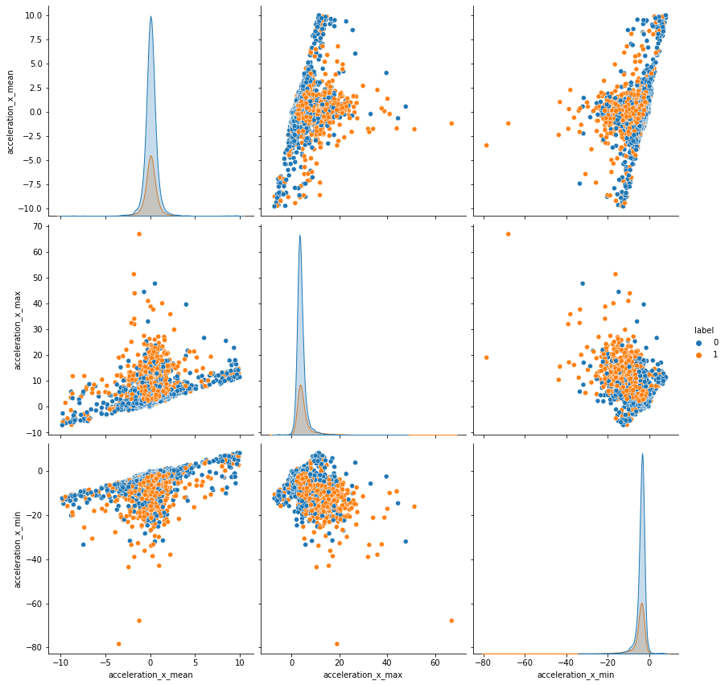

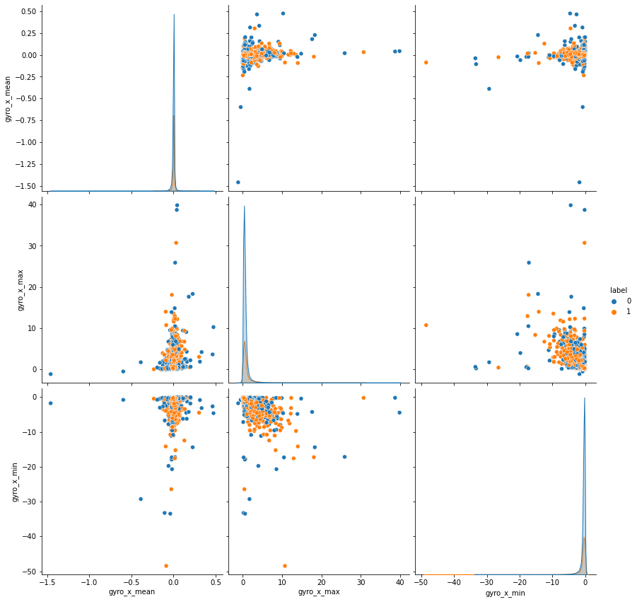

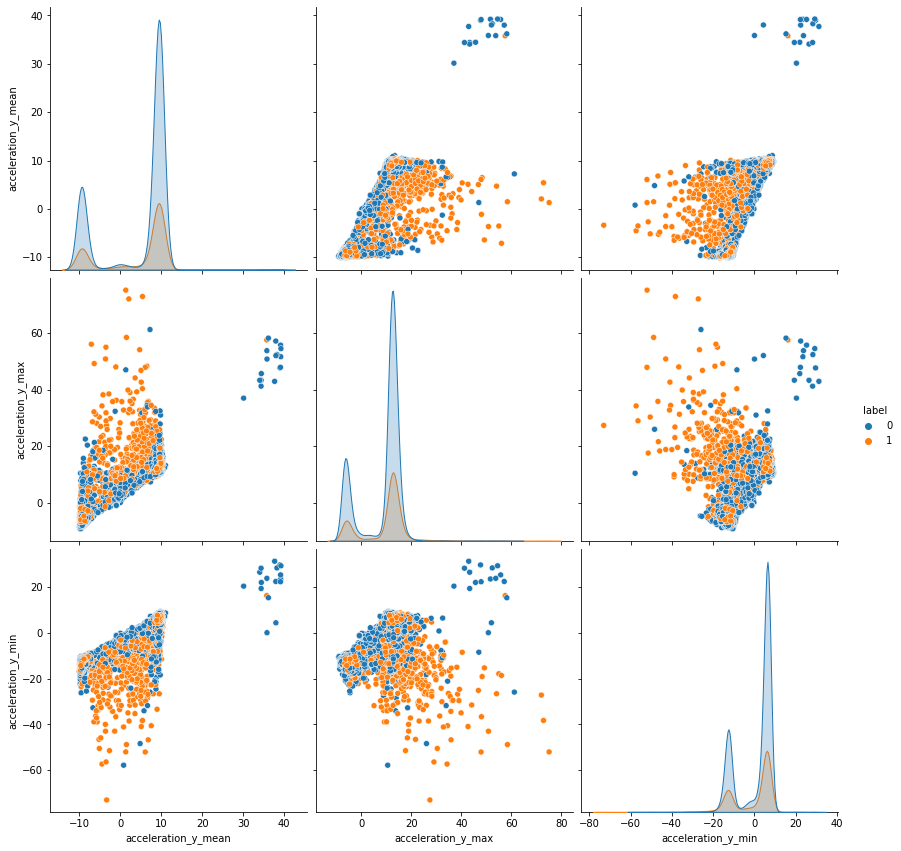

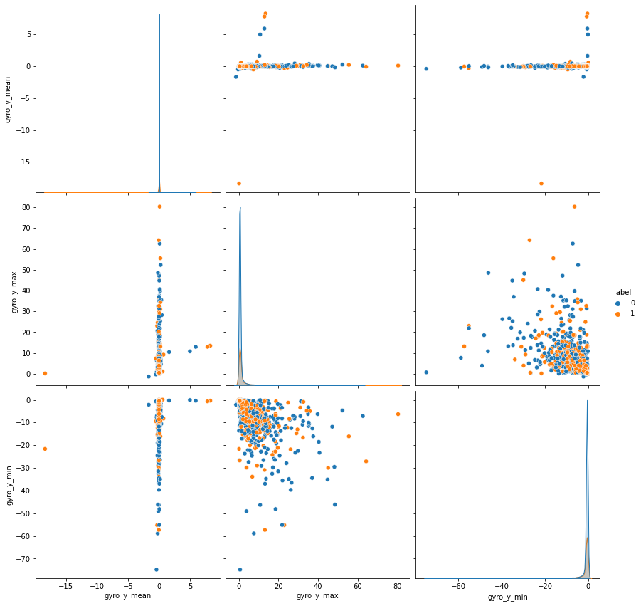

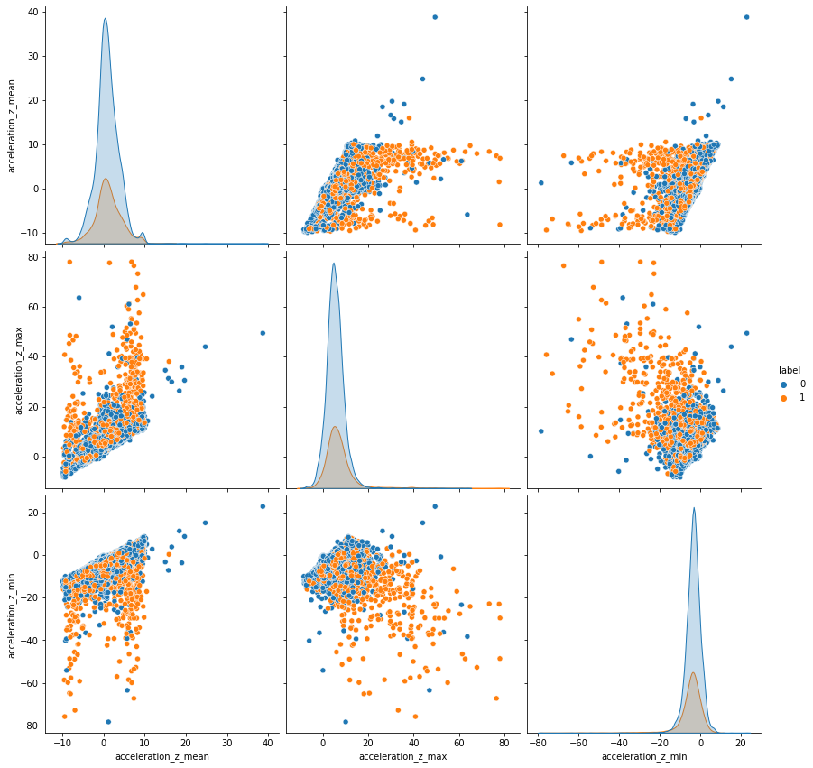

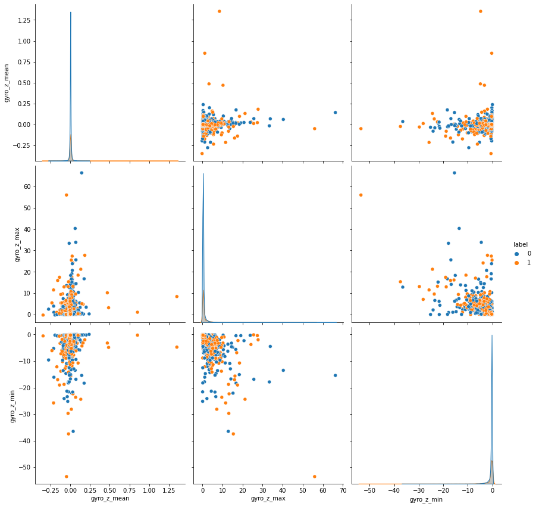

```python
for i in ['x', 'y', 'z']:
  sns.pairplot(agg_data[[f'acceleration_{i}_mean', f'acceleration_{i}_max', f'acceleration_{i}_min', 'label']], hue='label', height=4)
  plt.show()
  sns.pairplot(agg_data[[f'gyro_{i}_mean', f'gyro_{i}_max', f'gyro_{i}_min', 'label']], hue='label', height=4)
```

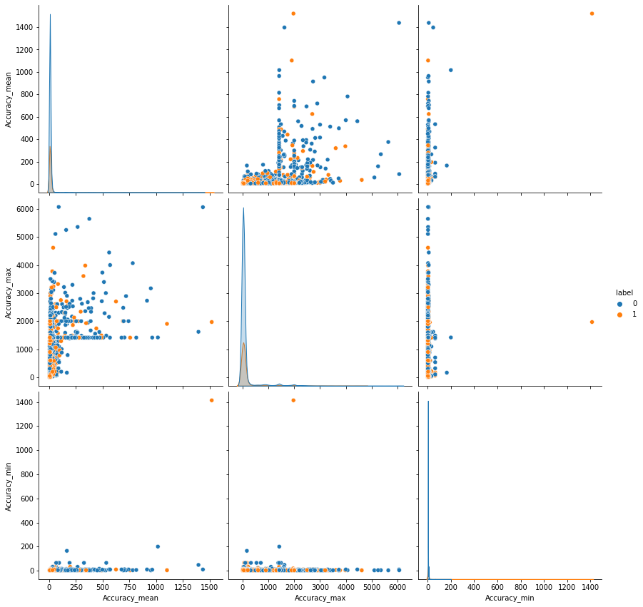

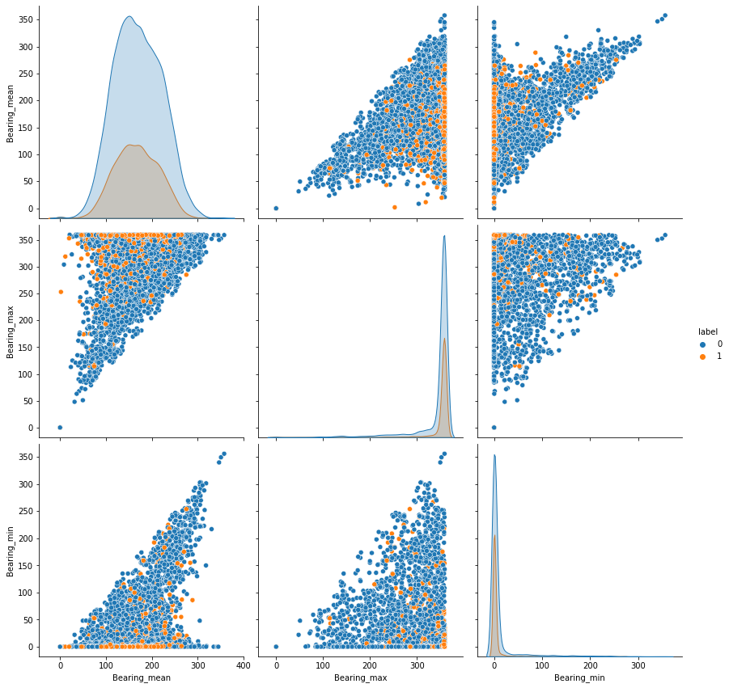

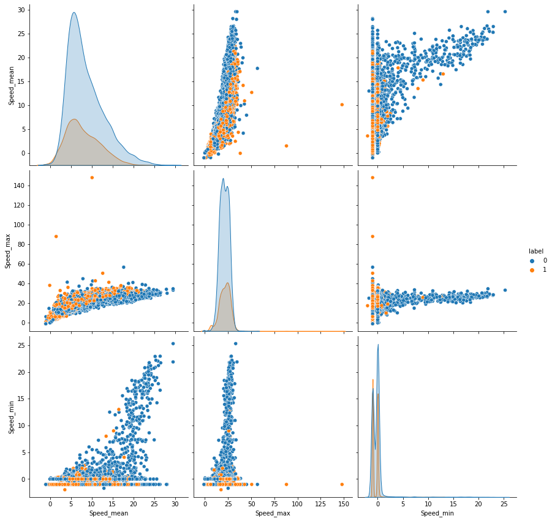

```python
for i in ['Accuracy', 'Bearing', 'Speed']:
  sns.pairplot(agg_data[[f'{i}_mean', f'{i}_max', f'{i}_min', 'label']], hue='label', height=4)
  plt.show()
```

As mentioned above, each bookingID trip was a sequence of data with multiple features like acceleration, gyro and speed for example. As such, our team decided to represent each bookingID trip sequential data as a single data point, thus giving us a dataset with each bookingID representing a datapoint. The way we aggregated the data was using statiscal features of the sequential data like mean, min and max.

We used a correlation matrix next to see which features are naturally more directly correlated to the label of dangerous trips. This would give us a good idea of the data, which statistical feature is directly correlated and thus would affect if a trip is dangerous.

From our results, we found out that in general min and max of the gyro/rotation of the phone in any of the axis had the highest correlation with a trip being labeled dangerous. Looking at the data from this point, this is quite possibly be because if a trip tends to turn a lot and fast(Per s), a trip is dangerous.

This was surprising as our team had expected speed or acceleration to be higher, but it does also make sense for gyro to have a high impact on indicating a dangerous trips.

Lastly, taking a closer look at the aggregated data in a pairplot, we can see no one of the features can really accurately indicate a dangerous trip, which falls in line with out team's inital thought that the sequence of data/trends in the data would be the factor in which we can determine a trip is dangerous.

## How does the driving behaviour change over time (second) for normal trips and dangerous trips? What are the behaviour difference?

|  | bookingID | Accuracy | Bearing | acceleration_x | acceleration_y | acceleration_z | gyro_x | gyro_y | gyro_z | second | Speed | label | acc_vec | acc_y |
| --- | --- | --- | --- | --- | --- | --- | --- | --- | --- | --- | --- | --- | --- | --- |
| 0 | 0 | 12.0 | 143.298294 | 0.818112 | -9.941461 | -2.014999 | -0.016245 | -0.094040 | 0.070732 | 0.0 | 3.442991 | 0 | 10.176551 | 9.941461 |
| 1 | 0 | 8.0 | 143.298294 | 0.546405 | -9.835590 | -2.038925 | -0.047092 | -0.078874 | 0.043187 | 1.0 | 0.228454 | 0 | 10.059553 | 9.835590 |
| 2 | 0 | 8.0 | 143.298294 | -1.706207 | -9.270792 | -1.209448 | -0.028965 | -0.032652 | 0.015390 | 2.0 | 0.228454 | 0 | 9.503762 | 9.270792 |
| 3 | 0 | 8.0 | 143.298294 | -1.416705 | -9.548032 | -1.860977 | -0.022413 | 0.005049 | -0.025753 | 3.0 | 0.228454 | 0 | 9.830320 | 9.548032 |
| 4 | 0 | 8.0 | 143.298294 | -0.598145 | -9.853534 | -1.378574 | -0.014297 | -0.046206 | 0.021902 | 4.0 | 0.228454 | 0 | 9.967466 | 9.853534 |
| ... | ... | ... | ... | ... | ... | ... | ... | ... | ... | ... | ... | ... | ... | ... |
| 963 | 0 | 8.0 | 1.318084 | -0.928021 | -9.903479 | 0.174359 | -0.072805 | -0.044613 | -0.067651 | 1585.0 | 14.514922 | 0 | 9.948393 | 9.903479 |
| 964 | 0 | 8.0 | 1.318084 | -1.458725 | -9.134714 | -1.335059 | 0.024747 | 0.060531 | -0.002654 | 1586.0 | 15.799594 | 0 | 9.346296 | 9.134714 |
| 965 | 0 | 8.0 | 1.318084 | -0.671866 | -10.223337 | -1.004584 | -0.009690 | -0.098571 | 0.014922 | 1587.0 | 16.543667 | 0 | 10.294523 | 10.223337 |
| 966 | 0 | 8.0 | 1.318084 | -0.269464 | -10.234253 | -1.925577 | -0.042335 | -0.064177 | -0.044309 | 1588.0 | 16.543667 | 0 | 10.417312 | 10.234253 |
| 967 | 0 | 8.0 | 1.318084 | -1.938287 | -8.782108 | -1.037183 | 0.020958 | -0.054220 | 0.013748 | 1589.0 | 17.500950 | 0 | 9.053072 | 8.782108 |

968 rows × 14 columns

|  | bookingID | Accuracy | Bearing | acceleration_x | acceleration_y | acceleration_z | gyro_x | gyro_y | gyro_z | second | Speed | label | acc_vec | acc_y |
| --- | --- | --- | --- | --- | --- | --- | --- | --- | --- | --- | --- | --- | --- | --- |
| count | 968.0 | 968.000000 | 968.000000 | 968.000000 | 968.000000 | 968.000000 | 968.000000 | 968.000000 | 968.000000 | 968.000000 | 968.000000 | 968.0 | 968.000000 | 968.000000 |
| mean | 0.0 | 10.190083 | 173.809683 | -0.714358 | -9.556420 | -1.637444 | 0.004188 | -0.004647 | -0.004626 | 892.571281 | 8.812747 | 0.0 | 9.825899 | 9.556420 |
| std | 0.0 | 3.820836 | 128.384316 | 0.877877 | 0.556549 | 1.112374 | 0.064915 | 0.096590 | 0.062481 | 535.440353 | 7.172970 | 0.0 | 0.532989 | 0.556549 |
| min | 0.0 | 4.000000 | 0.037464 | -3.681729 | -10.707236 | -6.251807 | -0.392537 | -0.609930 | -0.731892 | 0.000000 | -1.000000 | 0.0 | 6.457339 | 6.119916 |
| 25% | 0.0 | 8.000000 | 38.211140 | -1.164774 | -9.866880 | -2.218817 | -0.023763 | -0.044958 | -0.029706 | 245.750000 | 1.247851 | 0.0 | 9.605663 | 9.325709 |
| 50% | 0.0 | 8.000000 | 144.299423 | -0.726596 | -9.606500 | -1.612523 | 0.002810 | -0.001711 | -0.003462 | 1077.500000 | 8.225331 | 0.0 | 9.839046 | 9.606500 |
| 75% | 0.0 | 12.000000 | 310.239105 | -0.303259 | -9.325709 | -1.066604 | 0.033239 | 0.033175 | 0.020134 | 1331.250000 | 15.482234 | 0.0 | 10.089082 | 9.866880 |
| max | 0.0 | 48.000000 | 359.979767 | 3.626102 | -6.119916 | 2.318857 | 0.438371 | 0.469724 | 0.372807 | 1589.000000 | 22.946083 | 0.0 | 11.678808 | 10.707236 |

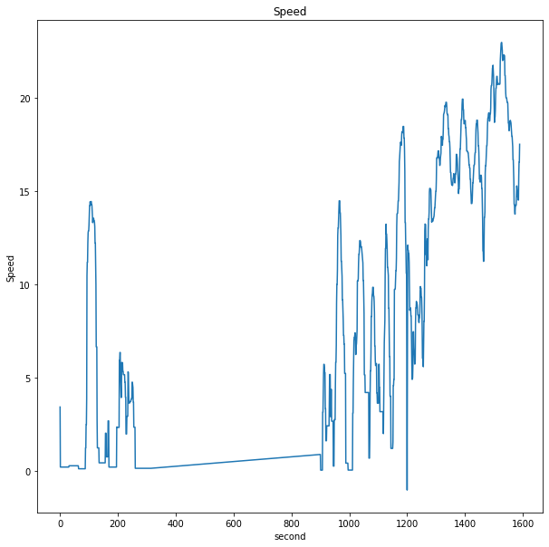

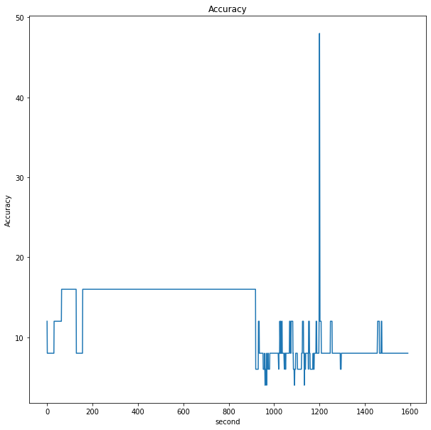

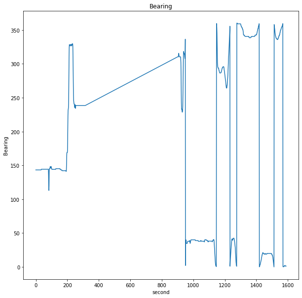

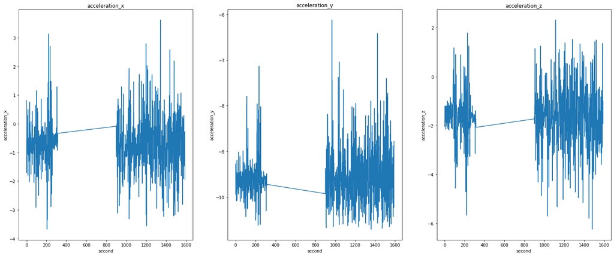

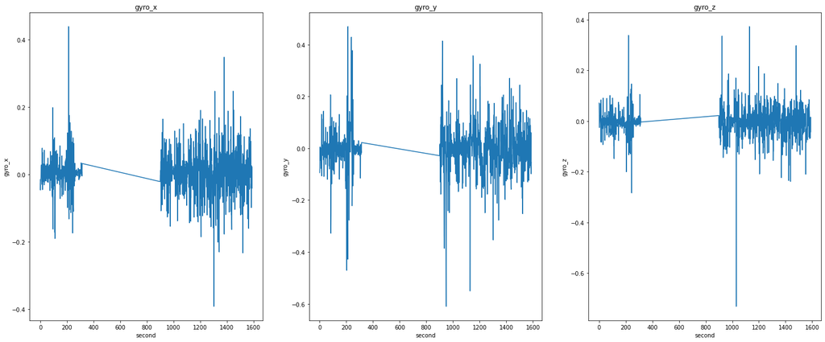

```python
# Data for just 1 trip
# Taking a safe trip
one_trip_data = ml_data[ml_data['bookingID'] == 0]
display(one_trip_data)
display(one_trip_data.describe())

one_trip_data['second'].values

fig, ax = plt.subplots(1, 1, figsize=(10, 10))
sns.lineplot(x='second', y='Speed', data=one_trip_data, ax=ax)
ax.set_title('Speed')

fig, ax = plt.subplots(1, 1, figsize=(10, 10))
sns.lineplot(x='second', y='Accuracy', data=one_trip_data, ax=ax)
ax.set_title('Accuracy')

fig, ax = plt.subplots(1, 1, figsize=(10, 10))
sns.lineplot(x='second', y='Bearing', data=one_trip_data, ax=ax)
ax.set_title('Bearing')

accs = ['acceleration_x', 'acceleration_y', 'acceleration_z']
gyros = ['gyro_x', 'gyro_y', 'gyro_z']

fig, ax = plt.subplots(1, 3, figsize=(25, 10))
for acc, axes in zip(accs, ax):
  sns.lineplot(x='second', y=acc, data=one_trip_data, ax=axes)
  axes.set_title(acc)

fig, ax = plt.subplots(1, 3, figsize=(25, 10))
for gyro, axes in zip(gyros, ax):
  sns.lineplot(x='second', y=gyro, data=one_trip_data, ax=axes)
  axes.set_title(gyro)
```

|  | bookingID | Accuracy | Bearing | acceleration_x | acceleration_y | acceleration_z | gyro_x | gyro_y | gyro_z | second | Speed | label | acc_vec | acc_y |
| --- | --- | --- | --- | --- | --- | --- | --- | --- | --- | --- | --- | --- | --- | --- |
| 968 | 1 | 4.0 | 252.0 | -1.394632 | 10.174141 | -2.503770 | 0.016127 | 0.212284 | -0.039776 | 0.0 | 4.756427 | 1 | 10.570100 | 10.174141 |
| 969 | 1 | 4.0 | 236.0 | -0.840489 | 8.749026 | -3.274607 | 0.037472 | 0.134862 | -0.011083 | 1.0 | 4.937211 | 1 | 9.379495 | 8.749026 |
| 970 | 1 | 4.0 | 228.0 | -1.944456 | 8.989030 | -2.978358 | -0.024487 | 0.102224 | -0.014870 | 2.0 | 5.544210 | 1 | 9.667171 | 8.989030 |
| 971 | 1 | 4.0 | 222.0 | -0.820675 | 9.282243 | -2.126961 | 0.007522 | 0.089431 | 0.006004 | 3.0 | 6.564030 | 1 | 9.558112 | 9.282243 |
| 972 | 1 | 4.0 | 216.0 | -1.020284 | 9.382215 | -2.618797 | -0.019007 | 0.002409 | -0.014382 | 4.0 | 7.358976 | 1 | 9.794133 | 9.382215 |
| ... | ... | ... | ... | ... | ... | ... | ... | ... | ... | ... | ... | ... | ... | ... |
| 1808 | 1 | 4.0 | 118.0 | -0.978453 | 9.906622 | -1.957212 | -0.043947 | 0.069429 | -0.014242 | 1030.0 | 9.938708 | 1 | 10.145403 | 9.906622 |
| 1809 | 1 | 4.0 | 112.0 | -0.499344 | 10.274085 | -2.085886 | 0.042970 | 0.124878 | 0.011746 | 1031.0 | 9.801586 | 1 | 10.495575 | 10.274085 |
| 1810 | 1 | 4.0 | 107.0 | -0.969680 | 9.218988 | -3.657564 | -0.069743 | -0.015900 | 0.004119 | 1032.0 | 9.683063 | 1 | 9.965330 | 9.218988 |
| 1811 | 1 | 4.0 | 105.0 | -0.984084 | 9.502673 | -2.788086 | -0.005690 | 0.025604 | -0.022637 | 1033.0 | 10.567403 | 1 | 9.952017 | 9.502673 |
| 1812 | 1 | 4.0 | 103.0 | -2.005977 | 9.764541 | -2.757900 | 0.009407 | 0.062448 | 0.019181 | 1034.0 | 11.556651 | 1 | 10.342931 | 9.764541 |

845 rows × 14 columns

|  | bookingID | Accuracy | Bearing | acceleration_x | acceleration_y | acceleration_z | gyro_x | gyro_y | gyro_z | second | Speed | label | acc_vec | acc_y |
| --- | --- | --- | --- | --- | --- | --- | --- | --- | --- | --- | --- | --- | --- | --- |
| count | 845.0 | 845.000000 | 845.000000 | 845.000000 | 845.000000 | 845.000000 | 845.000000 | 845.000000 | 845.000000 | 845.000000 | 845.000000 | 845.0 | 845.000000 | 845.000000 |
| mean | 1.0 | 3.716766 | 124.153846 | -0.511965 | 9.525570 | -2.199531 | -0.002572 | -0.008649 | 0.000537 | 582.304142 | 7.867199 | 1.0 | 9.852686 | 9.525570 |
| std | 0.0 | 0.599583 | 90.020640 | 0.701548 | 0.516699 | 0.856267 | 0.027305 | 0.089037 | 0.033454 | 289.237171 | 7.074278 | 0.0 | 0.501976 | 0.516699 |
| min | 1.0 | 3.000000 | 0.000000 | -3.493878 | 6.623425 | -5.355455 | -0.125367 | -0.678183 | -0.121265 | 0.000000 | -1.000000 | 1.0 | 6.970526 | 6.623425 |
| 25% | 1.0 | 3.000000 | 50.000000 | -0.839800 | 9.278796 | -2.579120 | -0.015533 | -0.033737 | -0.014835 | 393.000000 | 0.000000 | 1.0 | 9.603377 | 9.278796 |
| 50% | 1.0 | 3.900000 | 110.000000 | -0.561383 | 9.537963 | -2.178206 | -0.001518 | -0.003613 | -0.000384 | 609.000000 | 6.883418 | 1.0 | 9.843133 | 9.537963 |
| 75% | 1.0 | 4.000000 | 208.000000 | -0.228081 | 9.795474 | -1.822083 | 0.008587 | 0.022235 | 0.013334 | 821.000000 | 13.742122 | 1.0 | 10.102544 | 9.795474 |
| max | 1.0 | 7.709000 | 337.000000 | 3.813341 | 11.331690 | 1.481293 | 0.126536 | 0.324212 | 0.235131 | 1034.000000 | 21.882141 | 1.0 | 11.676235 | 11.331690 |

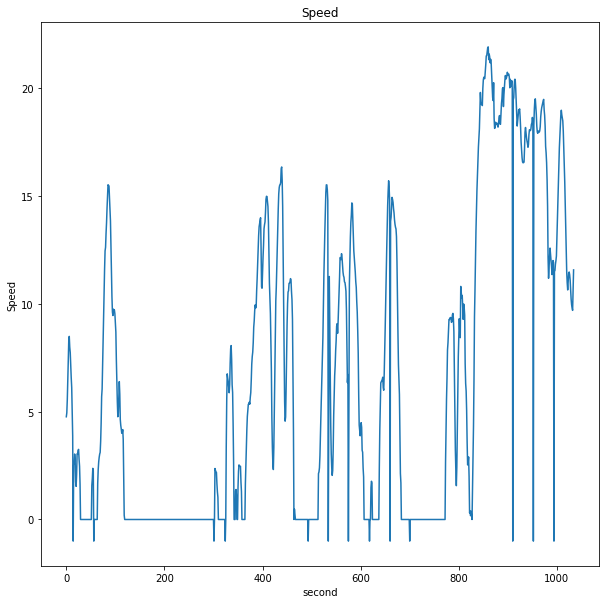

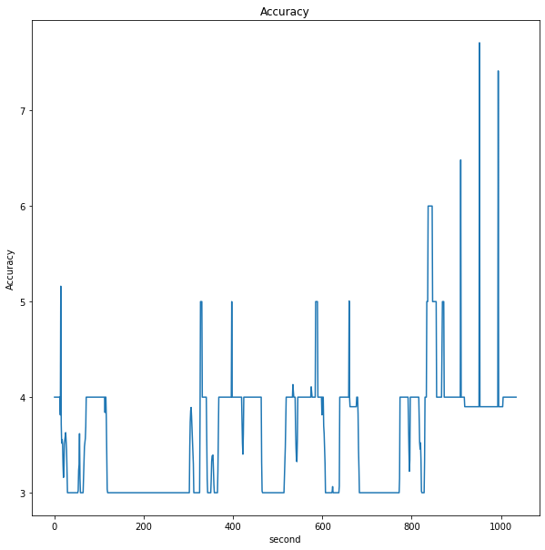

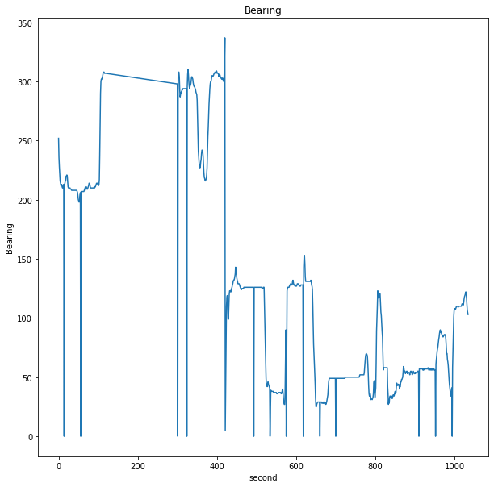

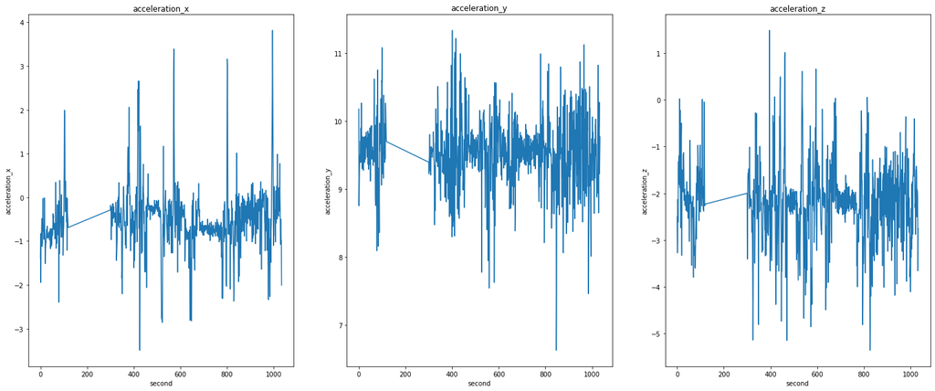

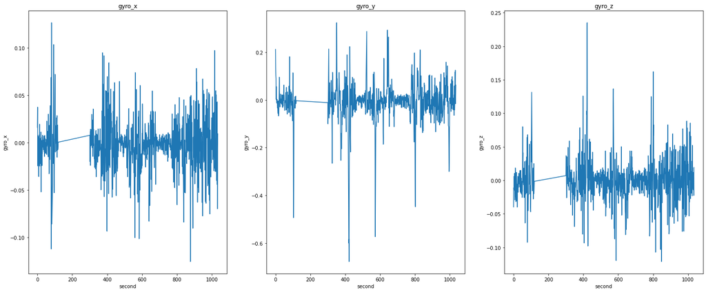

```python
# Data for just 1 trip
# Taking a dangerous trip
one_trip_data = ml_data[ml_data['bookingID'] == 1]
display(one_trip_data)
display(one_trip_data.describe())

one_trip_data['second'].values

fig, ax = plt.subplots(1, 1, figsize=(10, 10))
sns.lineplot(x='second', y='Speed', data=one_trip_data, ax=ax)
ax.set_title('Speed')

fig, ax = plt.subplots(1, 1, figsize=(10, 10))
sns.lineplot(x='second', y='Accuracy', data=one_trip_data, ax=ax)
ax.set_title('Accuracy')

fig, ax = plt.subplots(1, 1, figsize=(10, 10))
sns.lineplot(x='second', y='Bearing', data=one_trip_data, ax=ax)
ax.set_title('Bearing')

accs = ['acceleration_x', 'acceleration_y', 'acceleration_z']
gyros = ['gyro_x', 'gyro_y', 'gyro_z']

fig, ax = plt.subplots(1, 3, figsize=(25, 10))
for acc, axes in zip(accs, ax):
  sns.lineplot(x='second', y=acc, data=one_trip_data, ax=axes)
  axes.set_title(acc)

fig, ax = plt.subplots(1, 3, figsize=(25, 10))
for gyro, axes in zip(gyros, ax):
  sns.lineplot(x='second', y=gyro, data=one_trip_data, ax=axes)
  axes.set_title(gyro)
```

From the examples shown above we can see the visualization of the data for 2 trips, 1 non-dangerous and 1 dangerous.

For the other features, after looking at more different data points, it seems as though there are no sequential trends that can differente between a non-dangerous and dangerous trip. This is mostly due to the fact that our team does not really have a good way to compare these sequential data at once with other sequential data of different bookingIDs.

As such other than from the problem statement 1, we cannnot really say if there is much of a difference between dangerous and non-dangerous trips, even if comparing the change in behaviour over time. As such you will see us attempt to us deep learning later on to try and classify the trip, but classical ML models outperform the Deep Learning Model.

## Given the telematics data for new trips, derive a model to detect if the trip is a dangerous trip.

```python
print("Before oversampling")
print(f"x_train: {x_train.shape}, y_train: {y_train.shape}")

#* Oversampling the minority class
ros = RandomOverSampler(sampling_strategy = "minority", random_state = 29)
x_train, y_train = ros.fit_resample(x_train, y_train)

print("After oversampling")
print(f"x_train: {x_train.shape}, y_train: {y_train.shape}")
```

```
Before oversampling
x_train: (15919, 27), y_train: (15919,)
After oversampling
x_train: (23884, 27), y_train: (23884,)
```

We attempted to use a couple different Classification models in order to determine which would work the best.

Without any hyperparameter tuning, the Gradient Boosting Classifier obtained the greatest f1Score.

```python
modelSummary = pd.DataFrame({
    'Model': ["Logistic Regression", "Support Vector Machine", "Decision Tree Classifier", "AdaBoosting on Decision Tree", "Gradient Boosting Classifier", "AdaBoosting on Gradient Boosting Classifier"],
    'f1Score': [lrScore, svcScore, dtcScore, abc_dtc_Score, gbcScore, abc_gbc_Score]
})
modelSummary.sort_values(by="f1Score", ascending = False)
```

|  | Model | f1Score |
| --- | --- | --- |
| 4 | Gradient Boosting Classifier | 0.480296 |
| 0 | Logistic Regression | 0.466305 |
| 1 | Support Vector Machine | 0.400643 |
| 2 | Decision Tree Classifier | 0.374310 |
| 5 | AdaBoosting on Gradient Boosting Classifier | 0.365890 |
| 3 | AdaBoosting on Decision Tree | 0.359900 |

As such, we did a bit of hyperparameter tuning, using GridSearchCV as well as some manual tuning, in order to try to fine tune the model and try to get a better result.

```python
search = GridSearchCV(estimator = GradientBoostingClassifier(),
                      param_grid = {
                            'learning_rate': [0.1, 0.01],
                            'min_samples_split': [4, 8, 10],
                            'max_depth': [5, 7],
                            'subsample': [0.2, 0.4]
                      },
                      scoring = 'r2',
                      n_jobs = 8,
                      verbose = 1)
```

```
              precision    recall  f1-score   support

           0       0.85      0.72      0.78      2977
           1       0.42      0.61      0.50      1003

    accuracy                           0.69      3980
   macro avg       0.64      0.67      0.64      3980
weighted avg       0.74      0.69      0.71      3980
```

|  | 0 | 1 |
| --- | --- | --- |
| 0 | 2150 | 827 |
| 1 | 392 | 611 |

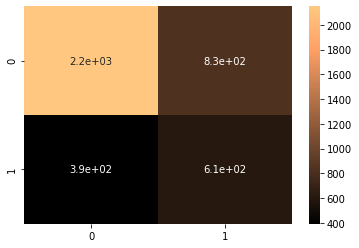

```python
#* Gradient Boosting Classifier
gbc_model = GradientBoostingClassifier(learning_rate = 0.01, max_depth = 2,
                                       min_samples_split = 7, subsample = 0.7,
                                       n_estimators = 1000)
gbc_model.fit(x_train, y_train)
gbcPreds = gbc_model.predict(x_test)

#* Evaluation
gbcReport = classification_report(y_test, gbcPreds)
print(gbcReport)
gbcScore = f1_score(y_test, gbcPreds)
rocAucScore = roc_auc_score(y_test, gbcPreds)

#* Confusion Matrix
cm = confusion_matrix(y_test, gbcPreds)
sns.heatmap(cm, annot=True, cmap='copper')

cm = pd.DataFrame(cm)
cm
```

```python
print(f"GBC f1 score: {gbcScore}")
print(f"GBC roc-auc score: {rocAucScore}")
```

```
GBC f1 score: 0.5006145022531749
GBC roc-auc score: 0.6656880215919256
```

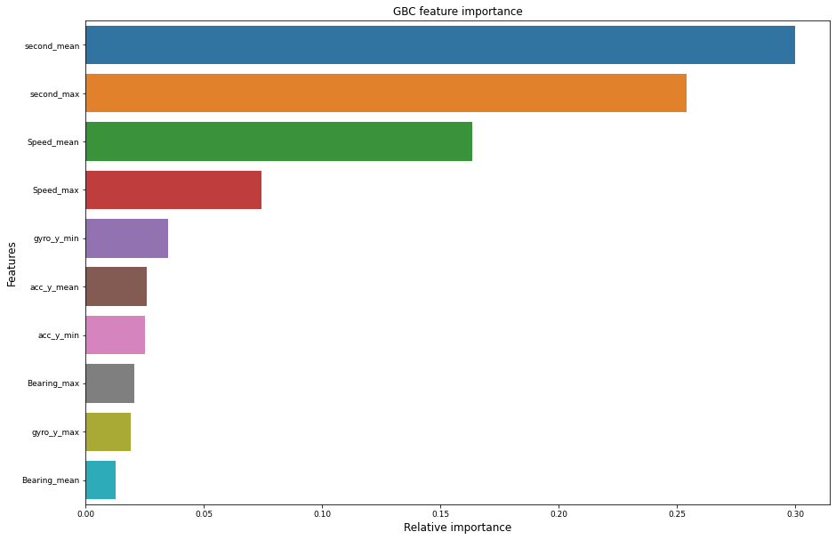

```python
# Showing feature importance for models that are able to
nrows = 1
ncols = 1
fig, axes = plt.subplots(nrows, ncols, sharex="all", figsize=(15, 10))

names_classifiers = [("GBC",gbc_model)]

nclassifier = 0
for row in range(nrows):
    for col in range(ncols):
        name = names_classifiers[nclassifier][0]
        classifier = names_classifiers[nclassifier][1]
        indices = np.argsort(classifier.feature_importances_)[::-1][:10]
        g = sns.barplot(y=trainingDf.columns[indices][:10],x = classifier.feature_importances_[indices][:10] , orient='h')
        g.set_xlabel("Relative importance",fontsize=12)
        g.set_ylabel("Features",fontsize=12)
        g.tick_params(labelsize=9)
        g.set_title(name + " feature importance")
        nclassifier += 1
```

# Our Process of dealing with the problem

## EDA, Feature Engineering and Processing

For the EDA of the dataset, most of it can be seen above, but the full code we used will be provided below.

For feature engineering, we made 2 new features:

1. acc_vec
   - Short for acceleration vector. This feature was made by taking magnitude of the sum of the x, y, z acceleration vector
   - This was done to hopdeully reduce the noise and dimensionality of the acceleration data, as only 1 axis had major change
2. acc_y
   - Short of acceleration y
   - This feature was made by taking the magnitude of the y acceleration vector.
   - This is because for most of the trips, the y axis was the axis in which represented trip/car movement.

```python
data = pd.read_csv('/content/drive/MyDrive/grab/Safety_DataSet_Aggregated.csv') # Loading in the dataset for the problem
```

```python
# Making copies to work on
dl_data = data
ml_data = data
```

First, based on the observation previously, it seems like the accerlation of x, y and z are not in the same direction all the time. As such I would like to treat them as vectors in 3 dirs and combine them into 1 vec taking just the magnitude. But before that, we also want to take a closer look at large outliers.

Furthermore, we can see previously that the values are distributed around 0, with negative values as well.  
Also it seems like for the x and z axis, they are usually noise, with the y acceleration contributing mainly to the car movement.

But using the combined magnitude of the vector, we can ignore this range of distribution around 0. Because what we care more about is the change in the acceleration than the actual values. This would also help both ML and DL model converge better.

We can then solve the issue of noise by taking the magnitude of just the y axis and using it as a feature as well.

```python
ml_data[[f'acceleration_{i}' for i in ['x', 'y', 'z']]].describe().apply(lambda x: x.apply('{0:.5f}'.format))
```

|  | acceleration_x | acceleration_y | acceleration_z |
| --- | --- | --- | --- |
| count | 16154418.00000 | 16154418.00000 | 16154418.00000 |
| mean | 0.06931 | 4.46436 | 0.89273 |
| std | 1.42370 | 8.13282 | 3.25289 |
| min | -78.41969 | -72.99412 | -78.44842 |
| 25% | -0.50782 | -2.11399 | -0.93377 |
| 50% | 0.06160 | 9.08121 | 0.77409 |
| 75% | 0.63538 | 9.70969 | 2.74907 |
| max | 66.87346 | 75.05589 | 78.05576 |

```python
# Looking more closely at the quantiles looking at 99 percent
display(ml_data[[f'acceleration_{i}' for i in ['x', 'y', 'z']]].quantile(0.999))
display(ml_data[[f'acceleration_{i}' for i in ['x', 'y', 'z']]].quantile(0.001))
# Looking at how many values outside this range
print(ml_data.shape[0] * (1- 0.999))

# q_999 = ml_data[[f'acceleration_{i}' for i in ['x', 'y', 'z']]].quantile(0.999).values
# q_001 = ml_data[[f'acceleration_{i}' for i in ['x', 'y', 'z']]].quantile(0.001).values

q_999 = ml_data[[f'acceleration_{i}' for i in ['x', 'y', 'z']]].quantile(0.99).values
q_001 = ml_data[[f'acceleration_{i}' for i in ['x', 'y', 'z']]].quantile(0.01).values
mask = None
for i, q999, q001 in zip(['x', 'y', 'z'], q_999, q_001):
  if mask is None:
    mask = ml_data[f'acceleration_{i}'] > q999
    mask = mask | (ml_data[f'acceleration_{i}'] < q001)
  else:
    mask = mask | (ml_data[f'acceleration_{i}'] > q999)
    mask = mask | (ml_data[f'acceleration_{i}'] < q001)

ml_data = ml_data[~mask]
ml_data

# Based of some back of the napkin calculations
# The fastest car accelerates at a rate of 100km in 2.3s -> 12m/s/s
# So some of these values still do not make sense but we will take the 99 percentile as the large outliers defintely do not make sense
# Could also be because of the accuracy
```

```
acceleration_x     9.765978
acceleration_y    18.820201
acceleration_z    13.302812
Name: 0.999, dtype: float64
```

```
acceleration_x    -9.401872
acceleration_y   -12.288668
acceleration_z   -10.617813
Name: 0.001, dtype: float64
```

```
16154.418000000014
```

|  | bookingID | Accuracy | Bearing | acceleration_x | acceleration_y | acceleration_z | gyro_x | gyro_y | gyro_z | second | Speed | label |
| --- | --- | --- | --- | --- | --- | --- | --- | --- | --- | --- | --- | --- |
| 0 | 0 | 12.0 | 143.298294 | 0.818112 | -9.941461 | -2.014999 | -0.016245 | -0.094040 | 0.070732 | 0.0 | 3.442991 | 0 |
| 1 | 0 | 8.0 | 143.298294 | 0.546405 | -9.835590 | -2.038925 | -0.047092 | -0.078874 | 0.043187 | 1.0 | 0.228454 | 0 |
| 2 | 0 | 8.0 | 143.298294 | -1.706207 | -9.270792 | -1.209448 | -0.028965 | -0.032652 | 0.015390 | 2.0 | 0.228454 | 0 |
| 3 | 0 | 8.0 | 143.298294 | -1.416705 | -9.548032 | -1.860977 | -0.022413 | 0.005049 | -0.025753 | 3.0 | 0.228454 | 0 |
| 4 | 0 | 8.0 | 143.298294 | -0.598145 | -9.853534 | -1.378574 | -0.014297 | -0.046206 | 0.021902 | 4.0 | 0.228454 | 0 |
| ... | ... | ... | ... | ... | ... | ... | ... | ... | ... | ... | ... | ... |
| 16154413 | 1709396983975 | 8.0 | 199.547104 | -0.320905 | -8.949738 | -3.971979 | -0.012879 | 0.015905 | -0.007625 | 559.0 | 1.035811 | 1 |
| 16154414 | 1709396983975 | 8.0 | 199.547104 | -0.418253 | -8.929102 | -3.950296 | -0.006455 | 0.005278 | -0.000082 | 560.0 | 1.035811 | 1 |
| 16154415 | 1709396983975 | 12.0 | 199.547104 | -0.226697 | -8.914597 | -4.338940 | 0.044719 | 0.032351 | -0.018600 | 561.0 | 0.302453 | 1 |
| 16154416 | 1709396983975 | 12.0 | 199.547104 | -0.372943 | -8.951382 | -4.416550 | 0.053263 | 0.029213 | -0.016357 | 562.0 | 0.302453 | 1 |
| 16154417 | 1709396983975 | 12.0 | 199.547104 | -0.024524 | -8.984430 | -3.973624 | -0.021494 | 0.000867 | 0.012516 | 563.0 | 0.302453 | 1 |

15229957 rows × 12 columns

```python
# Creating the vector to look at the values first
ml_data['acc_vec'] = np.sqrt(ml_data['acceleration_x']**2 + ml_data['acceleration_y']**2 + ml_data['acceleration_z']**2)
ml_data['acc_y'] = np.sqrt(ml_data['acceleration_y']**2)

display(ml_data['acc_vec'].describe().apply(lambda x: format(x, 'f')))
display(ml_data['acc_y'].describe().apply(lambda x: format(x, 'f')))
```

```
count    15229957.000000
mean            9.794472
std             0.655549
min             0.005074
25%             9.534295
50%             9.805519
75%            10.091374
max            15.138242
Name: acc_vec, dtype: object
```

```
count    15229957.000000
mean            9.208206
std             1.185775
min             0.000000
25%             8.891119
50%             9.469357
75%             9.812635
max            11.399506
Name: acc_y, dtype: object
```

```python
ml_data
```

|  | bookingID | Accuracy | Bearing | acceleration_x | acceleration_y | acceleration_z | gyro_x | gyro_y | gyro_z | second | Speed | label | acc_vec | acc_y |
| --- | --- | --- | --- | --- | --- | --- | --- | --- | --- | --- | --- | --- | --- | --- |
| 0 | 0 | 12.0 | 143.298294 | 0.818112 | -9.941461 | -2.014999 | -0.016245 | -0.094040 | 0.070732 | 0.0 | 3.442991 | 0 | 10.176551 | 9.941461 |
| 1 | 0 | 8.0 | 143.298294 | 0.546405 | -9.835590 | -2.038925 | -0.047092 | -0.078874 | 0.043187 | 1.0 | 0.228454 | 0 | 10.059553 | 9.835590 |
| 2 | 0 | 8.0 | 143.298294 | -1.706207 | -9.270792 | -1.209448 | -0.028965 | -0.032652 | 0.015390 | 2.0 | 0.228454 | 0 | 9.503762 | 9.270792 |
| 3 | 0 | 8.0 | 143.298294 | -1.416705 | -9.548032 | -1.860977 | -0.022413 | 0.005049 | -0.025753 | 3.0 | 0.228454 | 0 | 9.830320 | 9.548032 |
| 4 | 0 | 8.0 | 143.298294 | -0.598145 | -9.853534 | -1.378574 | -0.014297 | -0.046206 | 0.021902 | 4.0 | 0.228454 | 0 | 9.967466 | 9.853534 |
| ... | ... | ... | ... | ... | ... | ... | ... | ... | ... | ... | ... | ... | ... | ... |
| 16154413 | 1709396983975 | 8.0 | 199.547104 | -0.320905 | -8.949738 | -3.971979 | -0.012879 | 0.015905 | -0.007625 | 559.0 | 1.035811 | 1 | 9.796805 | 8.949738 |
| 16154414 | 1709396983975 | 8.0 | 199.547104 | -0.418253 | -8.929102 | -3.950296 | -0.006455 | 0.005278 | -0.000082 | 560.0 | 1.035811 | 1 | 9.772852 | 8.929102 |
| 16154415 | 1709396983975 | 12.0 | 199.547104 | -0.226697 | -8.914597 | -4.338940 | 0.044719 | 0.032351 | -0.018600 | 561.0 | 0.302453 | 1 | 9.917047 | 8.914597 |
| 16154416 | 1709396983975 | 12.0 | 199.547104 | -0.372943 | -8.951382 | -4.416550 | 0.053263 | 0.029213 | -0.016357 | 562.0 | 0.302453 | 1 | 9.988606 | 8.951382 |
| 16154417 | 1709396983975 | 12.0 | 199.547104 | -0.024524 | -8.984430 | -3.973624 | -0.021494 | 0.000867 | 0.012516 | 563.0 | 0.302453 | 1 | 9.823964 | 8.984430 |

15229957 rows × 14 columns

|  | bookingID | Accuracy | Bearing | acceleration_x | acceleration_y | acceleration_z | gyro_x | gyro_y | gyro_z | second | Speed | label | acc_vec | acc_y |
| --- | --- | --- | --- | --- | --- | --- | --- | --- | --- | --- | --- | --- | --- | --- |
| 16152907 | 1709396983971 | 8.155 | 2.0 | 1.494028 | 9.091062 | 3.416630 | 0.002334 | 0.005137 | -0.000694 | 0.0 | 0.000000 | 1 | 9.826133 | 9.091062 |
| 16152908 | 1709396983971 | 6.705 | 2.0 | 1.599376 | 8.930645 | 3.198751 | 0.004777 | -0.001582 | -0.005581 | 1.0 | 0.000000 | 1 | 9.620106 | 8.930645 |
| 16152909 | 1709396983971 | 6.872 | 2.0 | -0.620117 | 8.552350 | 4.110970 | 0.222856 | -1.047383 | 0.018243 | 2.0 | 0.000000 | 1 | 9.509328 | 8.552350 |
| 16152910 | 1709396983971 | 7.488 | 2.0 | -0.217879 | 8.784595 | 4.005622 | 0.030433 | -0.010134 | -0.003137 | 3.0 | 0.000000 | 1 | 9.657204 | 8.784595 |
| 16152911 | 1709396983971 | 8.560 | 2.0 | -0.287313 | 8.770228 | 4.065479 | 0.004166 | -0.039456 | 0.004804 | 4.0 | 0.000000 | 1 | 9.670965 | 8.770228 |
| ... | ... | ... | ... | ... | ... | ... | ... | ... | ... | ... | ... | ... | ... | ... |
| 16153979 | 1709396983971 | 4.771 | 254.0 | -0.610540 | 7.798153 | 6.004841 | 0.002334 | -0.036401 | -0.028183 | 1075.0 | 1.537477 | 1 | 9.861139 | 7.798153 |
| 16153980 | 1709396983971 | 4.828 | 259.0 | 0.007183 | 9.021627 | 3.940976 | -0.084409 | 0.026518 | 0.004804 | 1076.0 | 0.470755 | 1 | 9.844851 | 9.021627 |
| 16153981 | 1709396983971 | 4.416 | 259.0 | -0.222668 | 8.686429 | 3.955342 | -0.017825 | 0.008803 | 0.001139 | 1077.0 | 0.000000 | 1 | 9.547165 | 8.686429 |
| 16153982 | 1709396983971 | 4.176 | 259.0 | -0.136474 | 8.825297 | 4.175615 | -0.015382 | -0.010745 | 0.002360 | 1078.0 | 0.000000 | 1 | 9.764233 | 8.825297 |
| 16153983 | 1709396983971 | 4.024 | 259.0 | -0.148445 | 8.830086 | 4.127730 | 0.027379 | -0.005858 | 0.001750 | 1079.0 | 0.000000 | 1 | 9.748364 | 8.830086 |

1068 rows × 14 columns

|  | bookingID | Accuracy | Bearing | acceleration_x | acceleration_y | acceleration_z | gyro_x | gyro_y | gyro_z | second | Speed | label | acc_vec | acc_y |
| --- | --- | --- | --- | --- | --- | --- | --- | --- | --- | --- | --- | --- | --- | --- |
| count | 1.068000e+03 | 1068.000000 | 1068.000000 | 1068.000000 | 1068.000000 | 1068.000000 | 1068.000000 | 1068.000000 | 1068.000000 | 1068.000000 | 1068.000000 | 1068.0 | 1068.000000 | 1068.000000 |
| mean | 1.709397e+12 | 5.403723 | 204.342697 | 0.656020 | 8.883282 | 3.756185 | 0.003224 | 0.001024 | 0.000367 | 540.862360 | 6.213111 | 1.0 | 9.758086 | 8.883282 |
| std | 0.000000e+00 | 5.698160 | 107.323904 | 1.033763 | 0.593357 | 0.816972 | 0.062031 | 0.168599 | 0.064647 | 312.157667 | 5.653020 | 0.0 | 0.564144 | 0.593357 |
| min | 1.709397e+12 | 3.000000 | 0.000000 | -3.550709 | 5.542746 | 0.993624 | -0.696496 | -1.048605 | -0.372100 | 0.000000 | -1.000000 | 1.0 | 6.175481 | 5.542746 |
| 25% | 1.709397e+12 | 3.900000 | 103.000000 | -0.295094 | 8.623579 | 3.366350 | -0.012327 | -0.019450 | -0.011079 | 270.750000 | 0.000000 | 1.0 | 9.525388 | 8.623579 |
| 50% | 1.709397e+12 | 4.000000 | 243.000000 | 0.853559 | 8.852831 | 3.751829 | 0.002334 | 0.002694 | -0.003137 | 541.500000 | 5.614338 | 1.0 | 9.737470 | 8.852831 |
| 75% | 1.709397e+12 | 6.000000 | 290.000000 | 1.501210 | 9.150918 | 4.173820 | 0.015773 | 0.017355 | 0.009080 | 811.250000 | 11.266956 | 1.0 | 9.986839 | 9.150918 |
| max | 1.709397e+12 | 48.000000 | 359.000000 | 3.466910 | 11.190841 | 9.347249 | 0.342585 | 3.940942 | 0.929654 | 1079.000000 | 19.287226 | 1.0 | 12.303065 | 11.190841 |

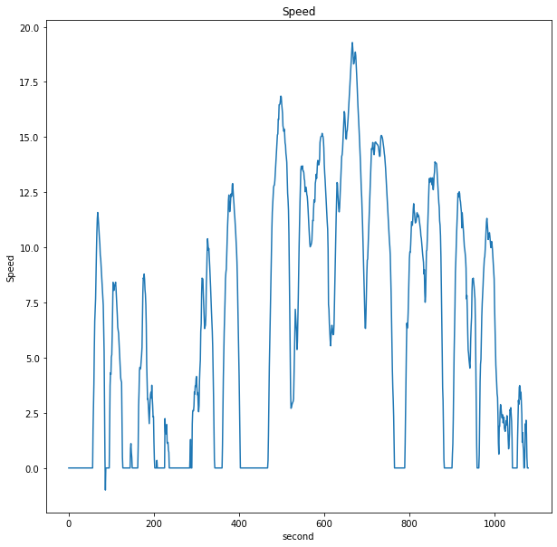

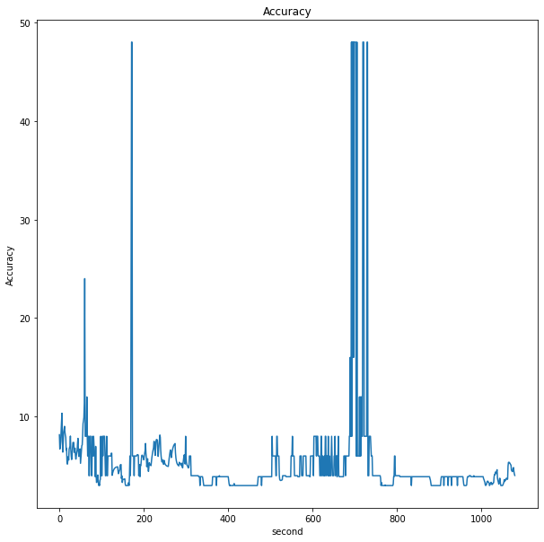

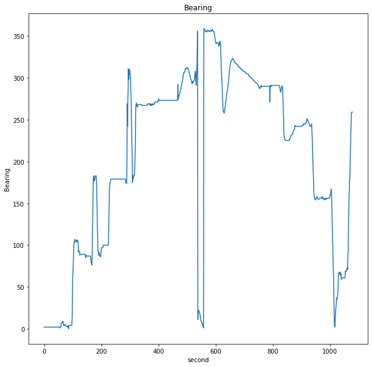

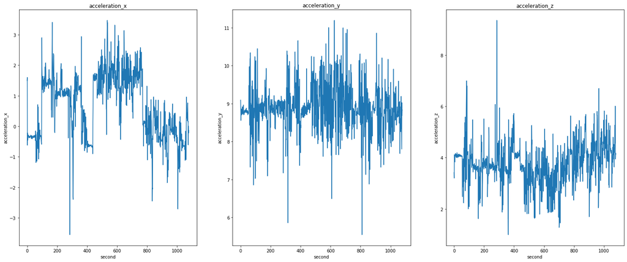

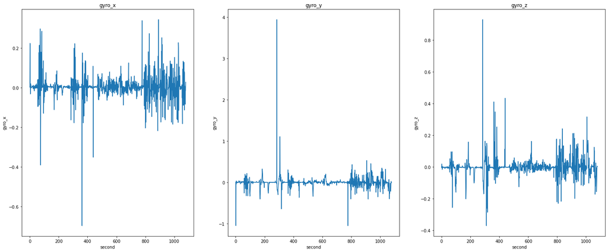

```python
# Looking at data for just 1 trip to see how it is like
# Taking a safe trip
one_trip_data = ml_data[ml_data['bookingID'] == 1709396983971]
display(one_trip_data)
display(one_trip_data.describe())

one_trip_data['second'].values

fig, ax = plt.subplots(1, 1, figsize=(10, 10))
sns.lineplot(x='second', y='Speed', data=one_trip_data, ax=ax)
ax.set_title('Speed')

fig, ax = plt.subplots(1, 1, figsize=(10, 10))
sns.lineplot(x='second', y='Accuracy', data=one_trip_data, ax=ax)
ax.set_title('Accuracy')

fig, ax = plt.subplots(1, 1, figsize=(10, 10))
sns.lineplot(x='second', y='Bearing', data=one_trip_data, ax=ax)
ax.set_title('Bearing')

accs = ['acceleration_x', 'acceleration_y', 'acceleration_z']
gyros = ['gyro_x', 'gyro_y', 'gyro_z']

fig, ax = plt.subplots(1, 3, figsize=(25, 10))
for acc, axes in zip(accs, ax):
  sns.lineplot(x='second', y=acc, data=one_trip_data, ax=axes)
  axes.set_title(acc)

fig, ax = plt.subplots(1, 3, figsize=(25, 10))
for gyro, axes in zip(gyros, ax):
  sns.lineplot(x='second', y=gyro, data=one_trip_data, ax=axes)
  axes.set_title(gyro)


# Few peculair things
# The seconds don't match up 1003 data points -> 1589 second? Some are missing
```

### Moving on to gyro data

From the previous section, some of the larger outliers do not make sense. (80rad/s -> 20 rotations/s)

We will be removing these outliers

```python
# Looking more closely at the quantiles looking at 99 percent
display(ml_data[[f'gyro_{i}' for i in ['x', 'y', 'z']]].quantile(0.999))
display(ml_data[[f'gyro_{i}' for i in ['x', 'y', 'z']]].quantile(0.001))
# Looking at how many values outside this range
print(ml_data.shape[0] * (1- 0.999))

q_999 = ml_data[[f'gyro_{i}' for i in ['x', 'y', 'z']]].quantile(0.999).values
q_001 = ml_data[[f'gyro_{i}' for i in ['x', 'y', 'z']]].quantile(0.001).values

# q_999 = ml_data[[f'acceleration_{i}' for i in ['x', 'y', 'z']]].quantile(0.99).values
# q_001 = ml_data[[f'acceleration_{i}' for i in ['x', 'y', 'z']]].quantile(0.01).values
mask = None
for i, q999, q001 in zip(['x', 'y', 'z'], q_999, q_001):
  if mask is None:
    mask = ml_data[f'gyro_{i}'] > q999
    mask = mask | (ml_data[f'gyro_{i}'] < q001)
  else:
    mask = mask | (ml_data[f'gyro_{i}'] > q999)
    mask = mask | (ml_data[f'gyro_{i}'] < q001)

mask.value_counts()
ml_data = ml_data[~mask]
ml_data
```

```
gyro_x    0.769237
gyro_y    1.902563
gyro_z    0.838746
Name: 0.999, dtype: float64
```

```
gyro_x   -0.779287
gyro_y   -1.666693
gyro_z   -0.741027
Name: 0.001, dtype: float64
```

```
15229.957000000013
```

|  | bookingID | Accuracy | Bearing | acceleration_x | acceleration_y | acceleration_z | gyro_x | gyro_y | gyro_z | second | Speed | label | acc_vec | acc_y |
| --- | --- | --- | --- | --- | --- | --- | --- | --- | --- | --- | --- | --- | --- | --- |
| 0 | 0 | 12.0 | 143.298294 | 0.818112 | -9.941461 | -2.014999 | -0.016245 | -0.094040 | 0.070732 | 0.0 | 3.442991 | 0 | 10.176551 | 9.941461 |
| 1 | 0 | 8.0 | 143.298294 | 0.546405 | -9.835590 | -2.038925 | -0.047092 | -0.078874 | 0.043187 | 1.0 | 0.228454 | 0 | 10.059553 | 9.835590 |
| 2 | 0 | 8.0 | 143.298294 | -1.706207 | -9.270792 | -1.209448 | -0.028965 | -0.032652 | 0.015390 | 2.0 | 0.228454 | 0 | 9.503762 | 9.270792 |
| 3 | 0 | 8.0 | 143.298294 | -1.416705 | -9.548032 | -1.860977 | -0.022413 | 0.005049 | -0.025753 | 3.0 | 0.228454 | 0 | 9.830320 | 9.548032 |
| 4 | 0 | 8.0 | 143.298294 | -0.598145 | -9.853534 | -1.378574 | -0.014297 | -0.046206 | 0.021902 | 4.0 | 0.228454 | 0 | 9.967466 | 9.853534 |
| ... | ... | ... | ... | ... | ... | ... | ... | ... | ... | ... | ... | ... | ... | ... |
| 16154413 | 1709396983975 | 8.0 | 199.547104 | -0.320905 | -8.949738 | -3.971979 | -0.012879 | 0.015905 | -0.007625 | 559.0 | 1.035811 | 1 | 9.796805 | 8.949738 |
| 16154414 | 1709396983975 | 8.0 | 199.547104 | -0.418253 | -8.929102 | -3.950296 | -0.006455 | 0.005278 | -0.000082 | 560.0 | 1.035811 | 1 | 9.772852 | 8.929102 |
| 16154415 | 1709396983975 | 12.0 | 199.547104 | -0.226697 | -8.914597 | -4.338940 | 0.044719 | 0.032351 | -0.018600 | 561.0 | 0.302453 | 1 | 9.917047 | 8.914597 |
| 16154416 | 1709396983975 | 12.0 | 199.547104 | -0.372943 | -8.951382 | -4.416550 | 0.053263 | 0.029213 | -0.016357 | 562.0 | 0.302453 | 1 | 9.988606 | 8.951382 |
| 16154417 | 1709396983975 | 12.0 | 199.547104 | -0.024524 | -8.984430 | -3.973624 | -0.021494 | 0.000867 | 0.012516 | 563.0 | 0.302453 | 1 | 9.823964 | 8.984430 |

15161685 rows × 14 columns

```python
ml_data[[f'gyro_{i}' for i in ['x', 'y', 'z']]].describe().apply(lambda s: s.apply('{0:.5f}'.format))
```

|  | gyro_x | gyro_y | gyro_z |
| --- | --- | --- | --- |
| count | 15161685.00000 | 15161685.00000 | 15161685.00000 |
| mean | -0.00175 | -0.00013 | -0.00033 |
| std | 0.08813 | 0.12357 | 0.06526 |
| min | -0.77929 | -1.66669 | -0.74103 |
| 25% | -0.02573 | -0.02886 | -0.01809 |
| 50% | -0.00067 | 0.00025 | -0.00004 |
| 75% | 0.02231 | 0.03015 | 0.01752 |
| max | 0.76922 | 1.90233 | 0.83875 |

### Looking at weird speed values

The weird values are the negative speed values.

```python
mask = ml_data['Speed'] < 0
ml_data[mask]['Speed'].value_counts()
# It seems like a majority of the negative values are -1
# This is likely a malfunction on the device
# We are going to change these values ot 0
```

```
-1.000000    187316
-0.018393         1
-0.003824         1
-0.143355         1
-0.197716         1
              ...
-0.072229         1
-0.171874         1
-0.171091         1
-0.072464         1
-0.104879         1
Name: Speed, Length: 3106, dtype: int64
```

```python
mask = ml_data['Speed'] == -1
ml_data.loc[mask]['Speed'] = 0
ml_data['Speed'].describe().apply(lambda x: format(x, 'f'))
```

```
count    15161685.000000
mean            8.967714
std             8.099042
min            -1.719776
25%             0.990000
50%             7.459117
75%            15.434342
max           148.018630
Name: Speed, dtype: object
```

### Making the final datasets

```python
dl_data = ml_data
dl_data = dl_data.drop([f'acceleration_{i}' for i in ['x', 'y', 'z']], axis=1)
```

```python
display(ml_data)
display(ml_data.describe().apply(lambda s: s.apply('{0:.5f}'.format)))
display(dl_data)
display(dl_data.describe().apply(lambda s: s.apply('{0:.5f}'.format)))
```

|  | bookingID | Accuracy | Bearing | acceleration_x | acceleration_y | acceleration_z | gyro_x | gyro_y | gyro_z | second | Speed | label | acc_vec | acc_y |
| --- | --- | --- | --- | --- | --- | --- | --- | --- | --- | --- | --- | --- | --- | --- |
| 0 | 0 | 12.0 | 143.298294 | 0.818112 | -9.941461 | -2.014999 | -0.016245 | -0.094040 | 0.070732 | 0.0 | 3.442991 | 0 | 10.176551 | 9.941461 |
| 1 | 0 | 8.0 | 143.298294 | 0.546405 | -9.835590 | -2.038925 | -0.047092 | -0.078874 | 0.043187 | 1.0 | 0.228454 | 0 | 10.059553 | 9.835590 |
| 2 | 0 | 8.0 | 143.298294 | -1.706207 | -9.270792 | -1.209448 | -0.028965 | -0.032652 | 0.015390 | 2.0 | 0.228454 | 0 | 9.503762 | 9.270792 |
| 3 | 0 | 8.0 | 143.298294 | -1.416705 | -9.548032 | -1.860977 | -0.022413 | 0.005049 | -0.025753 | 3.0 | 0.228454 | 0 | 9.830320 | 9.548032 |
| 4 | 0 | 8.0 | 143.298294 | -0.598145 | -9.853534 | -1.378574 | -0.014297 | -0.046206 | 0.021902 | 4.0 | 0.228454 | 0 | 9.967466 | 9.853534 |
| ... | ... | ... | ... | ... | ... | ... | ... | ... | ... | ... | ... | ... | ... | ... |
| 15161680 | 1709396983975 | 8.0 | 199.547104 | -0.320905 | -8.949738 | -3.971979 | -0.012879 | 0.015905 | -0.007625 | 559.0 | 1.035811 | 1 | 9.796805 | 8.949738 |
| 15161681 | 1709396983975 | 8.0 | 199.547104 | -0.418253 | -8.929102 | -3.950296 | -0.006455 | 0.005278 | -0.000082 | 560.0 | 1.035811 | 1 | 9.772852 | 8.929102 |
| 15161682 | 1709396983975 | 12.0 | 199.547104 | -0.226697 | -8.914597 | -4.338940 | 0.044719 | 0.032351 | -0.018600 | 561.0 | 0.302453 | 1 | 9.917047 | 8.914597 |
| 15161683 | 1709396983975 | 12.0 | 199.547104 | -0.372943 | -8.951382 | -4.416550 | 0.053263 | 0.029213 | -0.016357 | 562.0 | 0.302453 | 1 | 9.988606 | 8.951382 |
| 15161684 | 1709396983975 | 12.0 | 199.547104 | -0.024524 | -8.984430 | -3.973624 | -0.021494 | 0.000867 | 0.012516 | 563.0 | 0.302453 | 1 | 9.823964 | 8.984430 |

15161685 rows × 14 columns

|  | bookingID | Accuracy | Bearing | acceleration_x | acceleration_y | acceleration_z | gyro_x | gyro_y | gyro_z | second | Speed | label | acc_vec | acc_y |
| --- | --- | --- | --- | --- | --- | --- | --- | --- | --- | --- | --- | --- | --- | --- |
| count | 15161685.00000 | 15161685.00000 | 15161685.00000 | 15161685.00000 | 15161685.00000 | 15161685.00000 | 15161685.00000 | 15161685.00000 | 15161685.00000 | 15161685.00000 | 15161685.00000 | 15161685.00000 | 15161685.00000 | 15161685.00000 |
| mean | 818246121411.68689 | 10.89137 | 168.75781 | 0.06285 | 4.66325 | 0.89650 | -0.00175 | -0.00013 | -0.00033 | 4005.51488 | 8.96771 | 0.29758 | 9.79696 | 9.21533 |
| std | 494946986317.07629 | 82.51813 | 107.36156 | 1.00720 | 8.03398 | 2.87831 | 0.08813 | 0.12357 | 0.06526 | 1482109.32903 | 8.09904 | 0.45719 | 0.64581 | 1.16979 |
| min | 0.00000 | 0.75000 | 0.00000 | -3.68958 | -10.71382 | -8.11592 | -0.77929 | -1.66669 | -0.74103 | 0.00000 | -1.71978 | 0.00000 | 0.00786 | 0.00000 |
| 25% | 377957122225.00000 | 3.90000 | 78.00000 | -0.48604 | 1.30249 | -0.87432 | -0.02573 | -0.02886 | -0.01809 | 240.00000 | 0.99000 | 0.00000 | 9.53582 | 8.89576 |
| 50% | 807453851680.00000 | 4.00000 | 168.02567 | 0.06045 | 9.14374 | 0.78293 | -0.00067 | 0.00025 | -0.00004 | 517.00000 | 7.45912 | 0.00000 | 9.80589 | 9.47099 |
| 75% | 1254130450445.00000 | 8.00000 | 262.25410 | 0.61200 | 9.71597 | 2.68398 | 0.02231 | 0.03015 | 0.01752 | 858.00000 | 15.43434 | 1.00000 | 10.09148 | 9.81361 |
| max | 1709396983975.00000 | 6070.10100 | 359.99948 | 3.97928 | 11.39951 | 9.59386 | 0.76922 | 1.90233 | 0.83875 | 1495796757.00000 | 148.01863 | 1.00000 | 15.13824 | 11.39951 |

|  | bookingID | Accuracy | Bearing | gyro_x | gyro_y | gyro_z | second | Speed | label | acc_vec | acc_y |
| --- | --- | --- | --- | --- | --- | --- | --- | --- | --- | --- | --- |
| 0 | 0 | 12.0 | 143.298294 | -0.016245 | -0.094040 | 0.070732 | 0.0 | 3.442991 | 0 | 10.176551 | 9.941461 |
| 1 | 0 | 8.0 | 143.298294 | -0.047092 | -0.078874 | 0.043187 | 1.0 | 0.228454 | 0 | 10.059553 | 9.835590 |
| 2 | 0 | 8.0 | 143.298294 | -0.028965 | -0.032652 | 0.015390 | 2.0 | 0.228454 | 0 | 9.503762 | 9.270792 |
| 3 | 0 | 8.0 | 143.298294 | -0.022413 | 0.005049 | -0.025753 | 3.0 | 0.228454 | 0 | 9.830320 | 9.548032 |
| 4 | 0 | 8.0 | 143.298294 | -0.014297 | -0.046206 | 0.021902 | 4.0 | 0.228454 | 0 | 9.967466 | 9.853534 |
| ... | ... | ... | ... | ... | ... | ... | ... | ... | ... | ... | ... |
| 15161680 | 1709396983975 | 8.0 | 199.547104 | -0.012879 | 0.015905 | -0.007625 | 559.0 | 1.035811 | 1 | 9.796805 | 8.949738 |
| 15161681 | 1709396983975 | 8.0 | 199.547104 | -0.006455 | 0.005278 | -0.000082 | 560.0 | 1.035811 | 1 | 9.772852 | 8.929102 |
| 15161682 | 1709396983975 | 12.0 | 199.547104 | 0.044719 | 0.032351 | -0.018600 | 561.0 | 0.302453 | 1 | 9.917047 | 8.914597 |
| 15161683 | 1709396983975 | 12.0 | 199.547104 | 0.053263 | 0.029213 | -0.016357 | 562.0 | 0.302453 | 1 | 9.988606 | 8.951382 |
| 15161684 | 1709396983975 | 12.0 | 199.547104 | -0.021494 | 0.000867 | 0.012516 | 563.0 | 0.302453 | 1 | 9.823964 | 8.984430 |

15161685 rows × 11 columns

|  | bookingID | Accuracy | Bearing | gyro_x | gyro_y | gyro_z | second | Speed | label | acc_vec | acc_y |
| --- | --- | --- | --- | --- | --- | --- | --- | --- | --- | --- | --- |
| count | 15161685.00000 | 15161685.00000 | 15161685.00000 | 15161685.00000 | 15161685.00000 | 15161685.00000 | 15161685.00000 | 15161685.00000 | 15161685.00000 | 15161685.00000 | 15161685.00000 |
| mean | 818246121411.68689 | 10.89137 | 168.75781 | -0.00175 | -0.00013 | -0.00033 | 4005.51488 | 8.96771 | 0.29758 | 9.79696 | 9.21533 |
| std | 494946986317.07629 | 82.51813 | 107.36156 | 0.08813 | 0.12357 | 0.06526 | 1482109.32903 | 8.09904 | 0.45719 | 0.64581 | 1.16979 |
| min | 0.00000 | 0.75000 | 0.00000 | -0.77929 | -1.66669 | -0.74103 | 0.00000 | -1.71978 | 0.00000 | 0.00786 | 0.00000 |
| 25% | 377957122225.00000 | 3.90000 | 78.00000 | -0.02573 | -0.02886 | -0.01809 | 240.00000 | 0.99000 | 0.00000 | 9.53582 | 8.89576 |
| 50% | 807453851680.00000 | 4.00000 | 168.02567 | -0.00067 | 0.00025 | -0.00004 | 517.00000 | 7.45912 | 0.00000 | 9.80589 | 9.47099 |
| 75% | 1254130450445.00000 | 8.00000 | 262.25410 | 0.02231 | 0.03015 | 0.01752 | 858.00000 | 15.43434 | 1.00000 | 10.09148 | 9.81361 |
| max | 1709396983975.00000 | 6070.10100 | 359.99948 | 0.76922 | 1.90233 | 0.83875 | 1495796757.00000 | 148.01863 | 1.00000 | 15.13824 | 11.39951 |

```python
# save the final data
ml_data.to_csv('/content/drive/MyDrive/grab/ml_data.csv', index=False)
dl_data.to_csv('/content/drive/MyDrive/grab/dl_data.csv', index=False)
```

## Deep Learning approach

The DL models we are building will be a simple an LSTM RNN model. The model will have 2 LSTM Layers with a Dense Layer at the bottom.

Here we will be doing 2 instances of the DL model. One trained with the normal distribution of the data, the other with the Oversampled dangerous class.

```python
from sklearn.model_selection import train_test_split
from imblearn.over_sampling import RandomOverSampler
from tensorflow.keras.preprocessing import sequence

from tensorflow.keras.callbacks import EarlyStopping, History

import tensorflow.keras as K
import tensorflow as tf
```

### Inital data prep

Even though we have processed the dl_data.  
We still need to process it further into the sequences to be feed into the LSTM RNN network.

```python
dl_data = pd.read_csv('/content/drive/MyDrive/grab/dl_data.csv')
```

```python
dl_data
```

|  | bookingID | Accuracy | Bearing | gyro_x | gyro_y | gyro_z | second | Speed | label | acc_vec | acc_y |
| --- | --- | --- | --- | --- | --- | --- | --- | --- | --- | --- | --- |
| 0 | 0 | 12.0 | 143.298294 | -0.016245 | -0.094040 | 0.070732 | 0.0 | 3.442991 | 0 | 10.176551 | 9.941461 |
| 1 | 0 | 8.0 | 143.298294 | -0.047092 | -0.078874 | 0.043187 | 1.0 | 0.228454 | 0 | 10.059553 | 9.835590 |
| 2 | 0 | 8.0 | 143.298294 | -0.028965 | -0.032652 | 0.015390 | 2.0 | 0.228454 | 0 | 9.503762 | 9.270792 |
| 3 | 0 | 8.0 | 143.298294 | -0.022413 | 0.005049 | -0.025753 | 3.0 | 0.228454 | 0 | 9.830320 | 9.548032 |
| 4 | 0 | 8.0 | 143.298294 | -0.014297 | -0.046206 | 0.021902 | 4.0 | 0.228454 | 0 | 9.967466 | 9.853534 |
| ... | ... | ... | ... | ... | ... | ... | ... | ... | ... | ... | ... |
| 15161680 | 1709396983975 | 8.0 | 199.547104 | -0.012879 | 0.015905 | -0.007625 | 559.0 | 1.035811 | 1 | 9.796805 | 8.949738 |
| 15161681 | 1709396983975 | 8.0 | 199.547104 | -0.006455 | 0.005278 | -0.000082 | 560.0 | 1.035811 | 1 | 9.772852 | 8.929102 |
| 15161682 | 1709396983975 | 12.0 | 199.547104 | 0.044719 | 0.032351 | -0.018600 | 561.0 | 0.302453 | 1 | 9.917047 | 8.914597 |
| 15161683 | 1709396983975 | 12.0 | 199.547104 | 0.053263 | 0.029213 | -0.016357 | 562.0 | 0.302453 | 1 | 9.988606 | 8.951382 |
| 15161684 | 1709396983975 | 12.0 | 199.547104 | -0.021494 | 0.000867 | 0.012516 | 563.0 | 0.302453 | 1 | 9.823964 | 8.984430 |

15161685 rows × 11 columns

```python
# Dropping second to take it as 1 continous sequence
# Doing this because interpolating the data at this time is probably not realistic
dl_data = dl_data.drop(['second'], axis=1)
```

```python
# Creating new df by bookingID
dl = dl_data.set_index(['bookingID'])

# Grabbing the labels
l = dl.groupby(['bookingID'])['label'].max()
l = l.values
# Grabbing the data
d = [i[1].drop(['label'], axis=1).values for i in tuple(dl.groupby(['bookingID']))]
d = np.array(d)

print(f"Looking at d")
display(d)

pad_max = np.max([len(i) for i in d])
print(f"Pad max: {pad_max}")
```

```
Looking at d
```

[output not shown]

[output cut: 25 more lines]

[output not shown]

```
Pad max: 5954
```

```python
display(f"d shape: {d.shape}")
display(f"l shape: {l.shape}")

display(d[0])
display(l[0])
```

```
'd shape: (19899,)'
```

```
'l shape: (19899,)'
```

```
array([[ 1.20000000e+01,  1.43298294e+02, -1.62447500e-02, ...,
         3.44299054e+00,  1.01765505e+01,  9.94146118e+00],
       [ 8.00000000e+00,  1.43298294e+02, -4.70918786e-02, ...,
         2.28454471e-01,  1.00595525e+01,  9.83558960e+00],
       [ 8.00000000e+00,  1.43298294e+02, -2.89650726e-02, ...,
         2.28454471e-01,  9.50376166e+00,  9.27079163e+00],
       ...,
       [ 8.00000000e+00,  1.31808448e+00, -9.69017794e-03, ...,
         1.65436668e+01,  1.02945232e+01,  1.02233368e+01],
       [ 8.00000000e+00,  1.31808448e+00, -4.23354729e-02, ...,
         1.65436668e+01,  1.04173120e+01,  1.02342529e+01],
       [ 8.00000000e+00,  1.31808448e+00,  2.09582788e-02, ...,
         1.75009499e+01,  9.05307233e+00,  8.78210754e+00]])
```

```
0
```

### Inital LSTM RNN training

Here we will be using a padding to fill the values with 0. Then we will be cutting off the last 954 data points to be used as the seqence to be fed into the model.

This experiment we will be using the natural distribution of the unbalanced class for training.

```python
# Padding the sequences
d = sequence.pad_sequences(d, maxlen=pad_max)
d = d[:, 5000:, :] # last 1K data
d.shape
```

```
(19899, 954, 8)
```

```python
# Creating the train test split for the data
x_train, x_test, y_train, y_test = train_test_split(d, l.reshape(-1, 1))
print(x_train.shape)
print(x_test.shape)
print(y_train.shape)
print(y_test.shape)
```

```
(14924, 954, 8)
(4975, 954, 8)
(14924, 1)
(4975, 1)
```

```python
x_train
```

```
array([[[  0,   0,   0, ...,   0,   0,   0],
        [  0,   0,   0, ...,   0,   0,   0],
        [  0,   0,   0, ...,   0,   0,   0],
        ...,
        [  4,   0,   0, ...,   0,   9,   9],
        [  4,   0,   0, ...,   0,  10,  10],
        [  4,   0,   0, ...,   0,   9,   9]],

       [[  0,   0,   0, ...,   0,   0,   0],
        [  0,   0,   0, ...,   0,   0,   0],
        [  0,   0,   0, ...,   0,   0,   0],
        ...,
        [  7, 168,   0, ...,   2,   9,   8],
        [  7, 187,   0, ...,   3,   9,   9],
        [  9, 193,   0, ...,   4,   9,   8]],

       [[  0,   0,   0, ...,   0,   0,   0],
        [  0,   0,   0, ...,   0,   0,   0],
        [  0,   0,   0, ...,   0,   0,   0],
        ...,
        [  5,  76,   0, ...,  22,   9,   0],
        [  5, 109,   0, ...,  24,   8,   0],
        [  5, 119,   0, ...,  25,   9,   0]],

       ...,

       [[  0,   0,   0, ...,   0,   0,   0],
        [  0,   0,   0, ...,   0,   0,   0],
        [  0,   0,   0, ...,   0,   0,   0],
        ...,
        [  4, 190,   0, ...,  21,   9,   9],
        [  4, 192,   0, ...,  21,   9,   9],
        [  4, 193,   0, ...,  21,   9,   9]],

       [[  0,   0,   0, ...,   0,   0,   0],
        [  0,   0,   0, ...,   0,   0,   0],
        [  0,   0,   0, ...,   0,   0,   0],
        ...,
        [  3, 251,   0, ...,   1,   9,   7],
        [  3, 249,   0, ...,   1,   9,   7],
        [  3, 249,   0, ...,   0,   9,   7]],

       [[ 12, 350,   0, ...,   2,   9,   8],
        [ 12, 350,   0, ...,   2,   9,   8],
        [ 12, 350,   0, ...,   2,   9,   8],
        ...,
        [ 12, 243,   0, ...,   1,   9,   8],
        [ 12, 245,   0, ...,   1,   9,   8],
        [ 12, 252,   0, ...,   1,   9,   9]]], dtype=int32)
```

```python
y_train
```

```
array([[0],
       [0],
       [0],
       ...,
       [0],
       [0],
       [1]])
```

```python
# Making an LSTM model
from keras.layers import Conv1D, Dense, Dropout, Input, Concatenate, GlobalMaxPooling1D, LSTM, TimeDistributed
from keras.models import Model, Sequential

model = Sequential()

model.add(LSTM(500, return_sequences=True, batch_input_shape=(None, 954, 8)))
model.add(LSTM(500, return_sequences=False))
model.add(Dense(2, activation='softmax'))
model.summary()

model.compile(optimizer='adam', loss='binary_crossentropy', metrics=['binary_crossentropy'])
```

```
Model: "sequential"
_________________________________________________________________
Layer (type)                 Output Shape              Param #
=================================================================
lstm (LSTM)                  (None, 954, 500)          1018000
_________________________________________________________________
lstm_1 (LSTM)                (None, 500)               2002000
_________________________________________________________________
dense (Dense)                (None, 2)                 1002
=================================================================
Total params: 3,021,002
Trainable params: 3,021,002
Non-trainable params: 0
_________________________________________________________________
```

```python
model.fit(x_train, y_train, epochs=20, callbacks=[EarlyStopping(monitor='val_loss', min_delta=1e-6)], batch_size=16, validation_data=(x_test, y_test))
```

```
<tensorflow.python.keras.callbacks.History at 0x7f68d2e7d5c0>
```

```python
model.save('/content/drive/MyDrive/grab/lstm.h5', save_format='h5')
```

```python
preds = model.predict_classes(x_test)
preds
```

[output not shown]

```
array([0, 1, 0, ..., 1, 1, 0])
```

```
              precision    recall  f1-score   support

           0       0.75      0.95      0.83      3710
           1       0.27      0.06      0.10      1265

    accuracy                           0.72      4975
   macro avg       0.51      0.50      0.47      4975
weighted avg       0.63      0.72      0.65      4975

[[3511  199]
 [1191   74]]
```

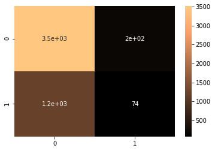

```python
print(classification_report(y_test, preds))
cm = confusion_matrix(y_test, preds)
print(cm)
sns.heatmap(cm, annot=True, cmap='copper')
```

### 2nd Experiment trying to oversample and balance the dataset

In this section, we balanaced the data using RandomOverSampling from imblearn, oversampling on the dagerous (1 label) data points.

We also used a much longer sequence length of the last 1954 data points for the sequence.

```python
d = sequence.pad_sequences(d, maxlen=pad_max)
d.shape
d = d[:, 4000:, :] # last 1K data

# Creating the train test split for the data
x_train, x_test, y_train, y_test = train_test_split(d, l.reshape(-1, 1))
print(x_train.shape)
print(x_test.shape)
print(y_train.shape)
print(y_test.shape)

from imblearn.over_sampling import RandomOverSampler
ros = RandomOverSampler(random_state=42, ratio=0.5, return_indices=True)
ros.fit_resample(x_train[:, :, 0], y_train)
x_train = x_train[ros.sample_indices_]
y_train = y_train[ros.sample_indices_]

print(x_train.shape)
print(y_train.shape)
```

```
(14924, 1954, 8)
(4975, 1954, 8)
(14924, 1)
(4975, 1)
```

```
(16842, 1954, 8)
(16842, 1)
```

```python
# Making an LSTM model
from keras.layers import Conv1D, Dense, Dropout, Input, Concatenate, GlobalMaxPooling1D, LSTM, TimeDistributed
from keras.models import Model, Sequential

model = Sequential()

model.add(LSTM(500, return_sequences=True, batch_input_shape=(None, 1954, 8)))
model.add(LSTM(500, return_sequences=False))
model.add(Dense(2, activation='softmax'))
model.summary()

model.compile(optimizer='adam', loss='binary_crossentropy', metrics=['binary_crossentropy'])
```

```
Model: "sequential_1"
_________________________________________________________________
Layer (type)                 Output Shape              Param #
=================================================================
lstm_2 (LSTM)                (None, 1954, 500)         1018000
_________________________________________________________________
lstm_3 (LSTM)                (None, 500)               2002000
_________________________________________________________________
dense_1 (Dense)              (None, 2)                 1002
=================================================================
Total params: 3,021,002
Trainable params: 3,021,002
Non-trainable params: 0
_________________________________________________________________
```

```python
model.fit(x_train, y_train, epochs=20, callbacks=[EarlyStopping(monitor='val_loss', min_delta=1e-6)], batch_size=32, validation_data=(x_test, y_test))
```

```
<tensorflow.python.keras.callbacks.History at 0x7fbe464befd0>
```

```python
model.save('/content/drive/MyDrive/grab/lstm_balanced.h5', save_format='h5')
```

```python
preds = model.predict_classes(x_test)
preds
```

[output not shown]

```
array([1, 1, 1, ..., 1, 1, 1])
```

```
              precision    recall  f1-score   support

           0       0.67      0.06      0.10      3691
           1       0.25      0.92      0.40      1284

    accuracy                           0.28      4975
   macro avg       0.46      0.49      0.25      4975
weighted avg       0.56      0.28      0.18      4975

[[ 207 3484]
 [ 102 1182]]
```

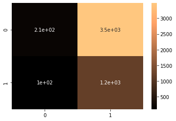

```python
print(classification_report(y_test, preds))
cm = confusion_matrix(y_test, preds)
print(cm)
sns.heatmap(cm, annot=True, cmap='copper')
```